# Mapping RNA on genome

Nastassia Gobet

27 June 2019 - 21 August 2019

# Data

Loading data

```r
# load data

# test parameters
Testpar <- read.table("F:/BXD/data/transcriptome/2_mapping_STAR/OnGenome/MappingStatisticsTEST_LB61nsd_onD2.tsv", header=FALSE, stringsAsFactors=FALSE)

# load stats for parental and F1 samples
B6mm10 <- read.table("F:/BXD/data/transcriptome/2_mapping_STAR/OnGenome/MappingStatisticsB6mm10_B6D2F1.tsv", header=TRUE, stringsAsFactors=FALSE, row.names="Sample_Name")
D2 <- read.table("F:/BXD/data/transcriptome/2_mapping_STAR/OnGenome/MappingStatisticsD2_B6D2F1.tsv", header=TRUE, stringsAsFactors=FALSE, row.names="Sample_Name")

# load stats for all samples
B6mm10all <- read.table("F:/BXD/data/transcriptome/2_mapping_STAR/OnGenome/MappingStatisticsB6mm10.tsv", header=TRUE, stringsAsFactors=FALSE, row.names="Sample_Name")
D2all <- read.table("F:/BXD/data/transcriptome/2_mapping_STAR/OnGenome/MappingStatisticsD2.tsv", header=TRUE, stringsAsFactors=FALSE, row.names="Sample_Name")


# test chromosomes and scaffolds to include
B6mm10primaryassembly <- read.table("F:/BXD/data/transcriptome/2_mapping_STAR/OnGenome/MappingStatisticsB6mm10primaryassembly_B6D2.tsv", header=TRUE, stringsAsFactors=FALSE, row.names="Sample_Name")
B6mm10primaryassemblynoscaffolds <- read.table("F:/BXD/data/transcriptome/2_mapping_STAR/OnGenome/MappingStatisticsB6mm10primaryassemblynoscaffolds_B6D2.tsv", header=TRUE, stringsAsFactors=FALSE, row.names="Sample_Name")
B6mm10majorchromosomes <- read.table("F:/BXD/data/transcriptome/2_mapping_STAR/OnGenome/MappingStatisticsB6mm10majorchromosomes_B6D2.tsv", header=TRUE, stringsAsFactors=FALSE, row.names="Sample_Name")
D2majorchromosomes <- read.table("F:/BXD/data/transcriptome/2_mapping_STAR/OnGenome/MappingStatisticsD2majorchromosomes_B6D2.tsv", header=TRUE, stringsAsFactors=FALSE, row.names="Sample_Name")

# load SraTable (for GSM to condition/line/tissue conversion)
sratable <- read.table("F:/BXD/data/transcriptome/RNAseq/SraRunTable.txt", sep="\t", header=TRUE, stringsAsFactors=FALSE)
##sratable[, c("Sample_Name", "condition", "genotype", "tissue")]
uniqSratmp <- unique(sratable[, c("Sample_Name", "condition", "genotype", "tissue")])
# display table with information on samples
##kable(uniqSra)
# load table to convert mouse lines names
MouseLines <- read.table("F:/BXD/data/ConvertLineNames.tsv", sep="\t", header=FALSE, stringsAsFactors=FALSE)

# clean mouse lines names in sra table
uniqSra <- uniqSratmp
rownames(uniqSra) <- 1:nrow(uniqSra)
uniqSra$genotype <- MouseLines$V1[match(uniqSratmp$genotype,MouseLines$V2)]
rm(uniqSratmp, MouseLines)
```

# Testing parameters

Just an idea about how the different parameters individually affect the uniquely mapped percentage. TESTfree is the default parameters of STAR.

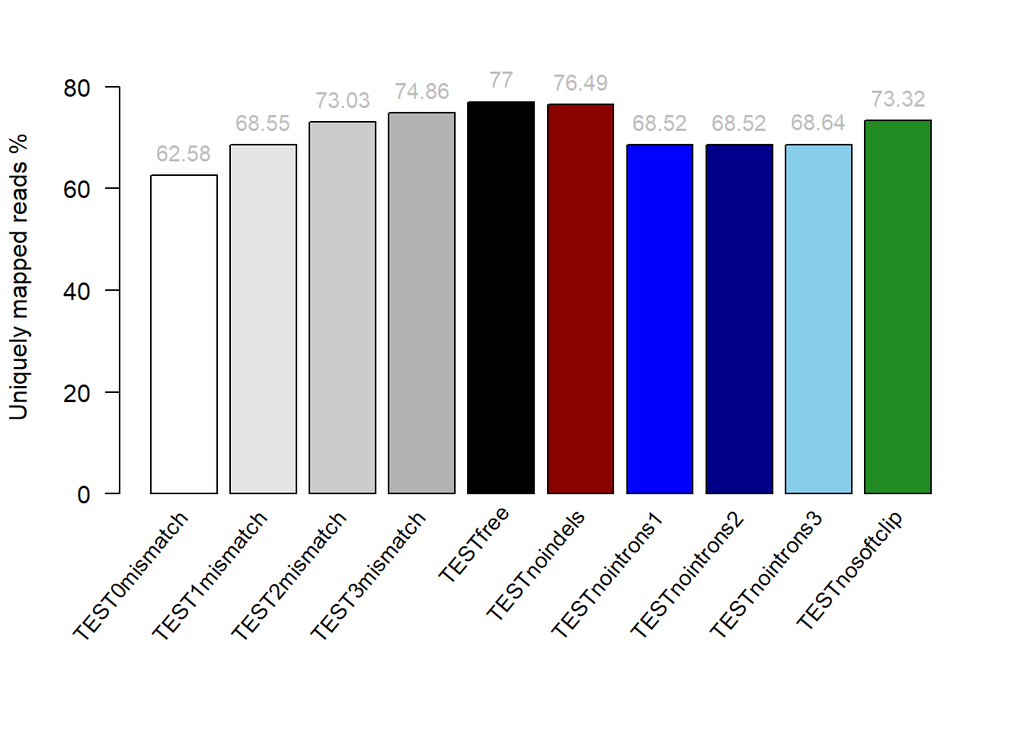

```r
# plot impact of different parameters tested individually.
par(mar=c(8.1,4.1,2.1,2.1))
xcor <- barplot(Testpar$V2[5:14], axisnames=FALSE, las=2, ylab="Uniquely mapped reads %", ylim=c(0,85), col=c("white","grey90","grey80", "grey70","black", "darkred","blue", "darkblue", "skyblue", "forestgreen"))
# add values above bars
text(x=xcor, y=Testpar$V2[5:14], label=Testpar$V2[5:14], pos=3, cex=0.9, col="grey")
#xlab
text(xcor, par("usr")[3], labels=Testpar$V1[5:14], srt=50, adj=c(1.1,1.1), xpd=TRUE, cex=0.9)
```

```r
# estimate uniquely mapped percentage if cumulative restriction (additive)
sum(Testpar$V2[9]-Testpar$V2[c(5,10,11,14)])
```

```
## [1] 27.09
```

# Unique percentage values

## on B6 mm10

```r
# display values B6 mm10
B6mm10all
```

|  | Uniq0 | Uniq1 | Uniq2 | Uniq3 | Uniq4 | Uniq5 |
| --- | --- | --- | --- | --- | --- | --- |
| 05nsd | 53.27 | 63.23 | 65.68 | 66.99 | 68.04 | 68.97 |
| 05sd | 53.16 | 62.99 | 65.43 | 66.78 | 67.86 | 68.84 |
| 100nsd | 54.25 | 64.08 | 66.42 | 67.68 | 68.67 | 69.58 |
| 100sd | 52.84 | 62.59 | 65.03 | 66.40 | 67.51 | 68.52 |
| 101nsd | 53.60 | 63.90 | 66.45 | 67.75 | 68.77 | 69.67 |
| 101sd | 53.31 | 63.99 | 66.59 | 67.90 | 68.92 | 69.82 |
| 103nsd | 53.98 | 63.59 | 66.01 | 67.31 | 68.32 | 69.22 |
| 103sd | 54.25 | 63.72 | 66.12 | 67.43 | 68.44 | 69.35 |
| 29nsd | 53.95 | 63.46 | 65.84 | 67.16 | 68.20 | 69.14 |
| 29sd | 54.09 | 63.08 | 65.40 | 66.75 | 67.83 | 68.81 |

[output cut: 166 more lines]

## on D2

```r
# display values D2
D2all
```

|  | Uniq0 | Uniq1 | Uniq2 | Uniq3 | Uniq4 | Uniq5 |
| --- | --- | --- | --- | --- | --- | --- |
| 05nsd | 49.66 | 60.34 | 64.02 | 66.57 | 68.55 | 70.05 |
| 05sd | 49.79 | 60.28 | 63.86 | 66.29 | 68.21 | 69.69 |
| 100nsd | 50.42 | 61.07 | 64.70 | 67.10 | 68.98 | 70.41 |
| 100sd | 49.33 | 59.91 | 63.55 | 65.98 | 67.90 | 69.39 |
| 101nsd | 51.91 | 62.42 | 65.88 | 68.21 | 70.01 | 71.38 |
| 101sd | 51.69 | 62.57 | 66.07 | 68.35 | 70.12 | 71.46 |
| 103nsd | 52.19 | 62.04 | 65.42 | 67.71 | 69.50 | 70.87 |
| 103sd | 52.48 | 62.19 | 65.55 | 67.82 | 69.61 | 70.99 |
| 29nsd | 50.78 | 61.18 | 64.70 | 67.02 | 68.84 | 70.25 |
| 29sd | 50.89 | 60.82 | 64.27 | 66.59 | 68.42 | 69.86 |

[output cut: 166 more lines]

## only parental and F1 samples

### on B6 mm10

```r
# display values B6 mm10
B6mm10
```

|  | Uniq0 | Uniq1 | Uniq2 | Uniq3 | Uniq4 | Uniq5 | Uniq6 | Uniq10 |
| --- | --- | --- | --- | --- | --- | --- | --- | --- |
| B61nsd | 53.92 | 61.60 | 63.64 | 64.97 | 66.12 | 67.19 | 68.20 | 71.76 |
| B61sd | 56.89 | 64.82 | 66.72 | 67.88 | 68.87 | 69.77 | 70.62 | 73.57 |
| B62nsd | 57.05 | 64.92 | 66.83 | 67.99 | 68.98 | 69.88 | 70.72 | 73.67 |
| B62sd | 56.43 | 64.33 | 66.27 | 67.48 | 68.51 | 69.47 | 70.36 | 73.49 |
| BDnsd | 52.25 | 61.03 | 63.52 | 65.01 | 66.22 | 67.33 | 68.36 | 71.99 |
| BDsd | 52.69 | 61.80 | 64.30 | 65.75 | 66.90 | 67.95 | 68.91 | 72.28 |
| DB1nsd | 51.50 | 61.85 | 64.80 | 66.33 | 67.47 | 68.45 | 69.35 | 72.48 |
| DB1sd | 50.81 | 61.23 | 64.21 | 65.77 | 66.94 | 67.96 | 68.90 | 72.17 |
| DB2nsd | 49.67 | 60.15 | 63.19 | 64.81 | 66.04 | 67.12 | 68.10 | 71.57 |
| DB2sd | 51.93 | 62.66 | 65.65 | 67.15 | 68.25 | 69.20 | 70.06 | 73.08 |

[output cut: 14 more lines]

### on D2

```r
# display values D2
D2
```

|  | Uniq0 | Uniq1 | Uniq2 | Uniq3 | Uniq4 | Uniq5 | Uniq6 | Uniq10 |
| --- | --- | --- | --- | --- | --- | --- | --- | --- |
| B61nsd | 46.16 | 56.73 | 60.72 | 63.39 | 65.45 | 67.05 | 68.40 | 73.05 |
| B61sd | 48.25 | 59.21 | 63.26 | 65.89 | 67.91 | 69.41 | 70.64 | 74.77 |
| B62nsd | 48.87 | 59.81 | 63.78 | 66.33 | 68.24 | 69.69 | 70.88 | 74.92 |
| B62sd | 48.41 | 59.32 | 63.27 | 65.78 | 67.71 | 69.19 | 70.42 | 74.58 |
| BDnsd | 50.31 | 59.56 | 62.95 | 65.34 | 67.25 | 68.77 | 70.06 | 74.51 |
| BDsd | 50.63 | 60.22 | 63.68 | 66.08 | 67.98 | 69.46 | 70.70 | 74.92 |
| DB1nsd | 55.63 | 63.73 | 66.50 | 68.57 | 70.27 | 71.60 | 72.71 | 76.45 |
| DB1sd | 54.91 | 63.14 | 65.94 | 68.00 | 69.72 | 71.07 | 72.21 | 76.05 |
| DB2nsd | 53.68 | 62.02 | 64.89 | 67.02 | 68.78 | 70.18 | 71.38 | 75.44 |
| DB2sd | 56.29 | 64.77 | 67.52 | 69.48 | 71.08 | 72.33 | 73.38 | 76.91 |

[output cut: 14 more lines]

# Analysis

## Parental samples

0 mismatch allowed

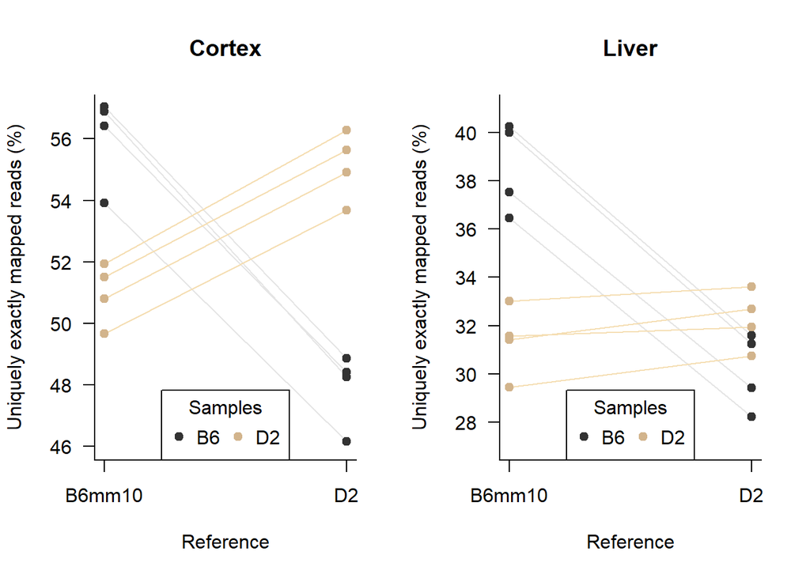

```r
# get parental samples indexes
CB6samples_idx <- intersect(grep("B6[12]", rownames(D2)), grep("L", rownames(D2), invert=TRUE))
CDBsamples_idx <- intersect(grep("DB[12]", rownames(D2)), grep("L", rownames(D2), invert=TRUE))
LB6samples_idx <- intersect(grep("B6[12]", rownames(D2)), grep("L", rownames(D2)))
LDBsamples_idx <- intersect(grep("DB[12]", rownames(D2)), grep("L", rownames(D2)))

# Difference in mappability by reference for uniquely exactly mapped reads
par(mfrow=c(1,2))

# in cortex
plot("", las=2, xlim=c(1,2), ylim=c(46,57), bty="l", xaxt="n", main="Cortex", xlab="Reference", ylab="Uniquely exactly mapped reads (%)")
axis(1, at=1:2, labels=c("B6mm10","D2"))
segments(x0=rep(2,8), y0=D2[c(CB6samples_idx,CDBsamples_idx),"Uniq0"], x1=rep(1,8), y1=B6mm10[c(CB6samples_idx,CDBsamples_idx),"Uniq0"],
         col=c(rep("grey90",4),rep("wheat",4)), lty = par("lty"), lwd = par("lwd"))
points(rep(1,8),B6mm10[c(CB6samples_idx,CDBsamples_idx),"Uniq0"], pch=19, cex=1, col=c(rep("grey20",4),rep("tan",4)))
points(rep(2,8),D2[c(CB6samples_idx,CDBsamples_idx),"Uniq0"], pch=19, cex=1, col=c(rep("grey20",4),rep("tan",4)))
legend("bottom", title="Samples", legend=c("B6","D2"), pch=19, col=c("grey20","tan"), horiz=TRUE)

# in liver
plot("", las=2, xlim=c(1,2), ylim=c(27,41), bty="l", xaxt="n", main="Liver", xlab="Reference", ylab="Uniquely exactly mapped reads (%)")
axis(1, at=1:2, labels=c("B6mm10","D2"))
segments(x0=rep(2,8), y0=D2[c(LB6samples_idx,LDBsamples_idx),"Uniq0"], x1=rep(1,8), y1=B6mm10[c(LB6samples_idx,LDBsamples_idx),"Uniq0"],
         col=c(rep("grey90",4),rep("wheat",4)), lty=par("lty"), lwd=1)
points(rep(1,8),B6mm10[c(LB6samples_idx,LDBsamples_idx),"Uniq0"], pch=19, cex=1, col=c(rep("grey20",4),rep("tan",4)))
points(rep(2,8),D2[c(LB6samples_idx,LDBsamples_idx),"Uniq0"], pch=19, cex=1, col=c(rep("grey20",4),rep("tan",4)))
legend("bottom", title="Samples", legend=c("B6","D2"), pch=19, col=c("grey20","tan"), horiz=TRUE)
```

Observations:

- In cortex, B6 samples map better on B6 reference, and D2 samples map better on D2.
- In liver, B6 samples still map better on B6 reference than on D2 reference, but D2 samples seem to map more similarly to both genomes.

## Parental and F1 samples

### 0

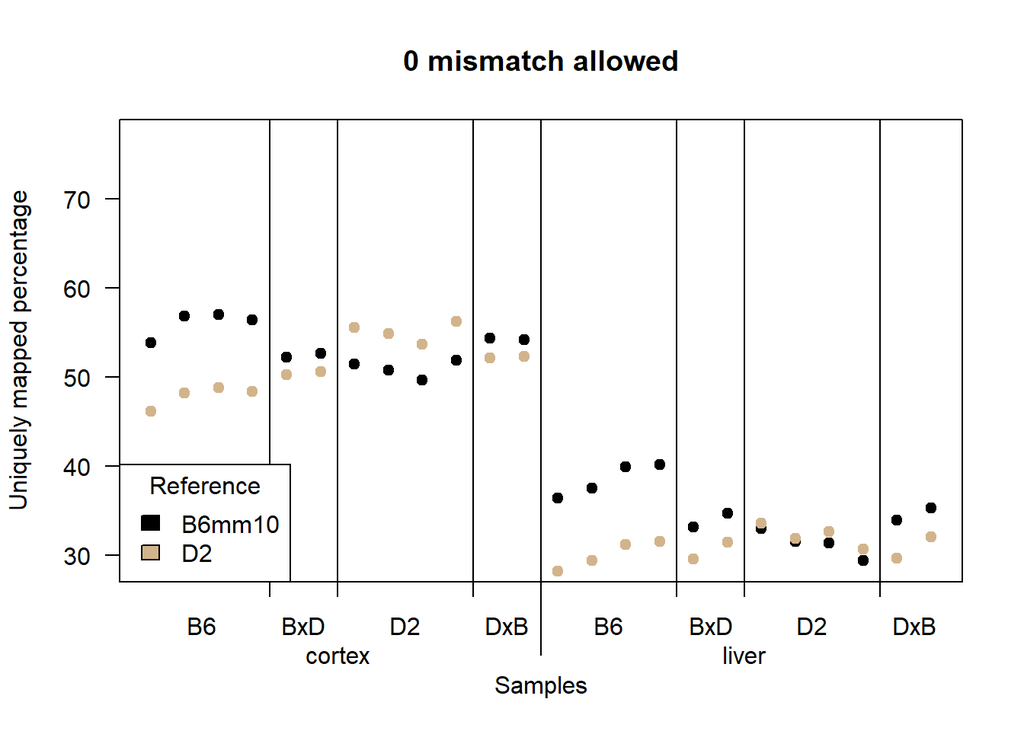

```r
# exactly matching
plot(B6mm10$Uniq0, pch=19, col="black", ylim=c(29,77), las=2, xaxt="n", ylab="Uniquely mapped percentage", xlab="Samples", main="0 mismatch allowed")
points(D2$Uniq0, pch=19, col="tan")
abline(v=c(4.5,6.5,10.5,12.5,16.5,18.5,22.5))
axis(1, at=c(4.5,6.5,10.5,12.5,16.5,18.5,22.5), labels=rep(c(""),7))
axis(1, at=c(c(2.5,5.5,8.5,11.5),12+c(2.5,5.5,8.5,11.5)), tick=FALSE, labels=rep(c("B6","BxD","D2","DxB"),2))
for(myline in seq(0.5,2,0.5)){
  axis(1, at=12.5, line=myline, labels=c(""))
}
axis(1, at=c(6.5,18.5), line=1, tick=FALSE, labels=c("cortex", "liver"))
legend("bottomleft", title="Reference", legend=c("B6mm10","D2"), fill=c("black","tan"))
```

Observations:

- About 15% of difference in mappability between cortex and liver (liver lower). The variability seems globally similar.
- B6 and D2 samples behave as expected (B6 samples maps higher on B6 reference, D2 samples maps higher on D2 reference), though the difference is very low for liver D2 samples mapped on D2.
- F1 samples map higher on B6 than on D2.

### 1

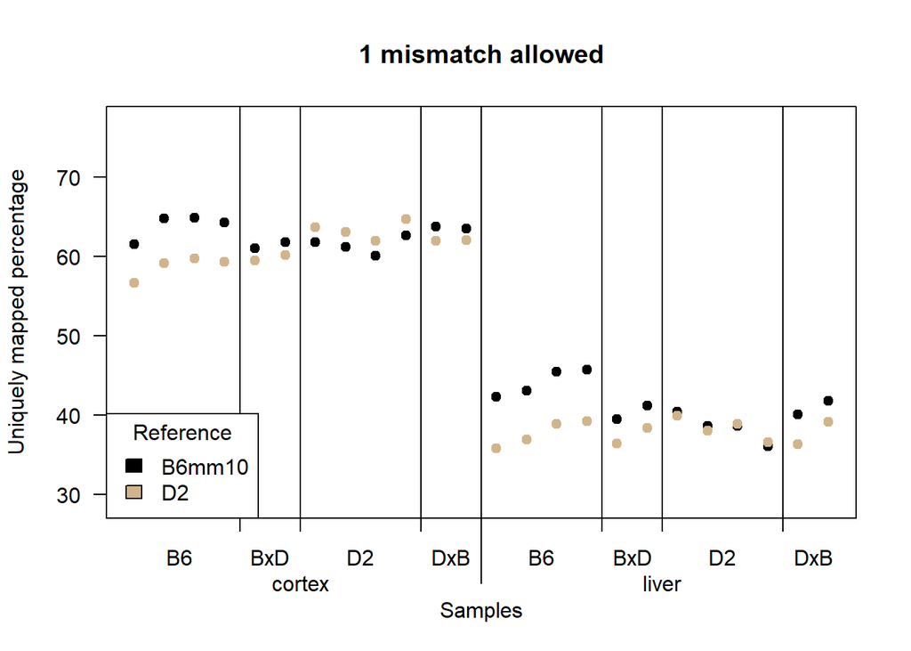

```r
# 1 mismatch allowed
plot(B6mm10$Uniq1, pch=19, col="black", ylim=c(29,77), las=2, xaxt="n", ylab="Uniquely mapped percentage", xlab="Samples", main="1 mismatch allowed")
points(D2$Uniq1, pch=19, col="tan")
abline(v=c(4.5,6.5,10.5,12.5,16.5,18.5,22.5))
axis(1, at=c(4.5,6.5,10.5,12.5,16.5,18.5,22.5), labels=rep(c(""),7))
axis(1, at=c(c(2.5,5.5,8.5,11.5),12+c(2.5,5.5,8.5,11.5)), tick=FALSE, labels=rep(c("B6","BxD","D2","DxB"),2))
for(myline in seq(0.5,2,0.5)){
  axis(1, at=12.5, line=myline, labels=c(""))
}
axis(1, at=c(6.5,18.5), line=1, tick=FALSE, labels=c("cortex", "liver"))
legend("bottomleft", title="Reference", legend=c("B6mm10","D2"), fill=c("black","tan"))
```

### 2

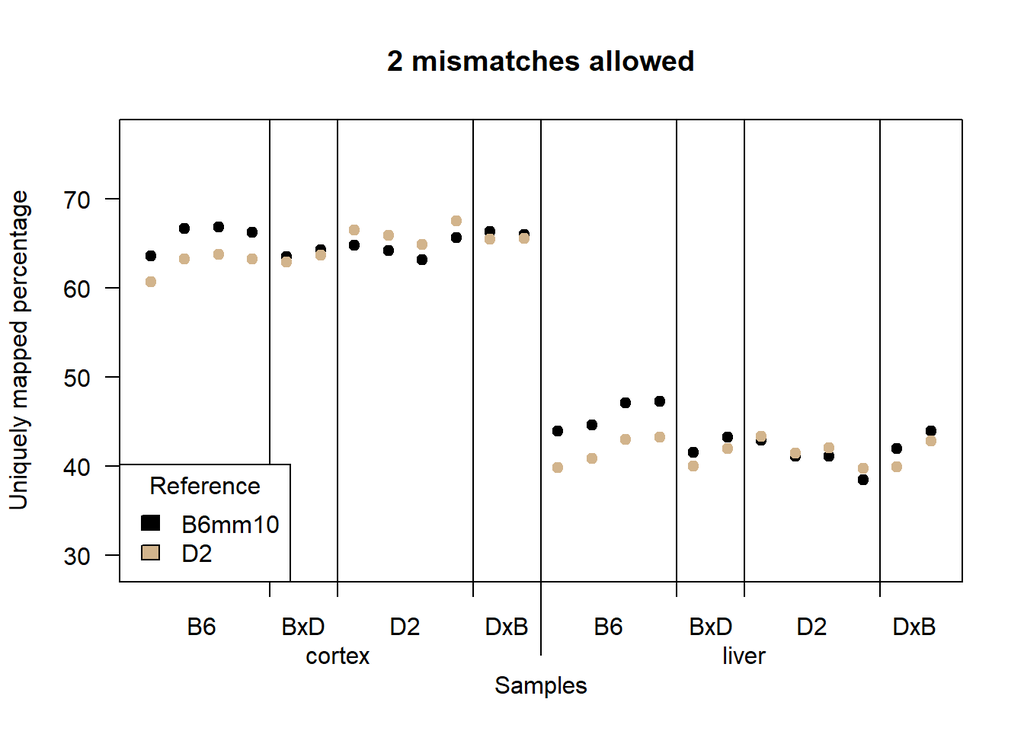

```r
# 2 mismatches allowed
plot(B6mm10$Uniq2, pch=19, col="black", ylim=c(29,77), las=2, xaxt="n", ylab="Uniquely mapped percentage", xlab="Samples", main="2 mismatches allowed")
points(D2$Uniq2, pch=19, col="tan")
abline(v=c(4.5,6.5,10.5,12.5,16.5,18.5,22.5))
axis(1, at=c(4.5,6.5,10.5,12.5,16.5,18.5,22.5), labels=rep(c(""),7))
axis(1, at=c(c(2.5,5.5,8.5,11.5),12+c(2.5,5.5,8.5,11.5)), tick=FALSE, labels=rep(c("B6","BxD","D2","DxB"),2))
for(myline in seq(0.5,2,0.5)){
  axis(1, at=12.5, line=myline, labels=c(""))
}
axis(1, at=c(6.5,18.5), line=1, tick=FALSE, labels=c("cortex", "liver"))
legend("bottomleft", title="Reference", legend=c("B6mm10","D2"), fill=c("black","tan"))
```

### 3

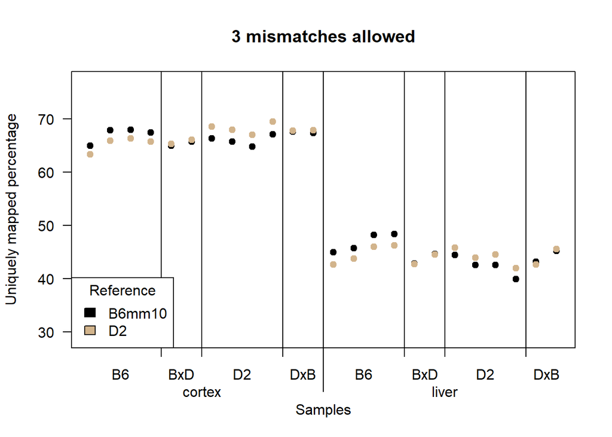

```r
# 3 mismatches allowed
plot(B6mm10$Uniq3, pch=19, col="black", ylim=c(29,77), las=2, xaxt="n", ylab="Uniquely mapped percentage", xlab="Samples", main="3 mismatches allowed")
points(D2$Uniq3, pch=19, col="tan")
abline(v=c(4.5,6.5,10.5,12.5,16.5,18.5,22.5))
axis(1, at=c(4.5,6.5,10.5,12.5,16.5,18.5,22.5), labels=rep(c(""),7))
axis(1, at=c(c(2.5,5.5,8.5,11.5),12+c(2.5,5.5,8.5,11.5)), tick=FALSE, labels=rep(c("B6","BxD","D2","DxB"),2))
for(myline in seq(0.5,2,0.5)){
  axis(1, at=12.5, line=myline, labels=c(""))
}
axis(1, at=c(6.5,18.5), line=1, tick=FALSE, labels=c("cortex", "liver"))
legend("bottomleft", title="Reference", legend=c("B6mm10","D2"), fill=c("black","tan"))
```

With 2 or 3 mismatches allowed, the F1 samples seem to map more similarly to both references.

### 4

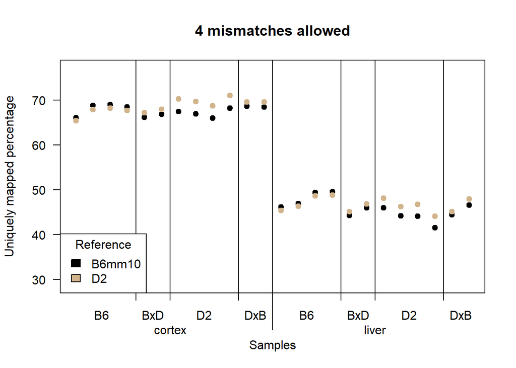

```r
# 4 mismatches allowed
plot(B6mm10$Uniq4, pch=19, col="black", ylim=c(29,77), las=2, xaxt="n", ylab="Uniquely mapped percentage", xlab="Samples", main="4 mismatches allowed")
points(D2$Uniq4, pch=19, col="tan")
abline(v=c(4.5,6.5,10.5,12.5,16.5,18.5,22.5))
axis(1, at=c(4.5,6.5,10.5,12.5,16.5,18.5,22.5), labels=rep(c(""),7))
axis(1, at=c(c(2.5,5.5,8.5,11.5),12+c(2.5,5.5,8.5,11.5)), tick=FALSE, labels=rep(c("B6","BxD","D2","DxB"),2))
for(myline in seq(0.5,2,0.5)){
  axis(1, at=12.5, line=myline, labels=c(""))
}
axis(1, at=c(6.5,18.5), line=1, tick=FALSE, labels=c("cortex", "liver"))
legend("bottomleft", title="Reference", legend=c("B6mm10","D2"), fill=c("black","tan"))
```

### 5

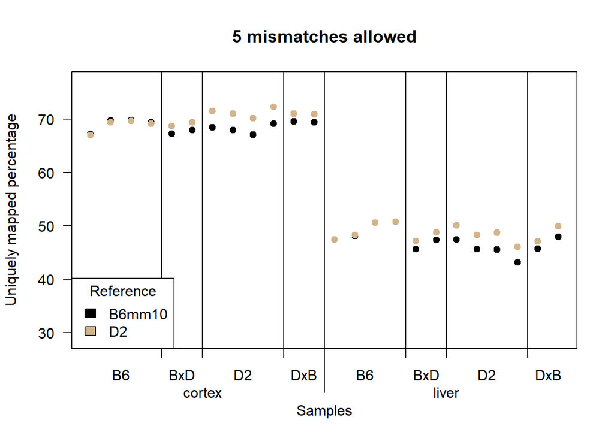

```r
# 5 mismatches allowed
plot(B6mm10$Uniq5, pch=19, col="black", ylim=c(29,77), las=2, xaxt="n", ylab="Uniquely mapped percentage", xlab="Samples", main="5 mismatches allowed")
points(D2$Uniq5, pch=19, col="tan")
abline(v=c(4.5,6.5,10.5,12.5,16.5,18.5,22.5))
axis(1, at=c(4.5,6.5,10.5,12.5,16.5,18.5,22.5), labels=rep(c(""),7))
axis(1, at=c(c(2.5,5.5,8.5,11.5),12+c(2.5,5.5,8.5,11.5)), tick=FALSE, labels=rep(c("B6","BxD","D2","DxB"),2))
for(myline in seq(0.5,2,0.5)){
  axis(1, at=12.5, line=myline, labels=c(""))
}
axis(1, at=c(6.5,18.5), line=1, tick=FALSE, labels=c("cortex", "liver"))
legend("bottomleft", title="Reference", legend=c("B6mm10","D2"), fill=c("black","tan"))
```

### 6

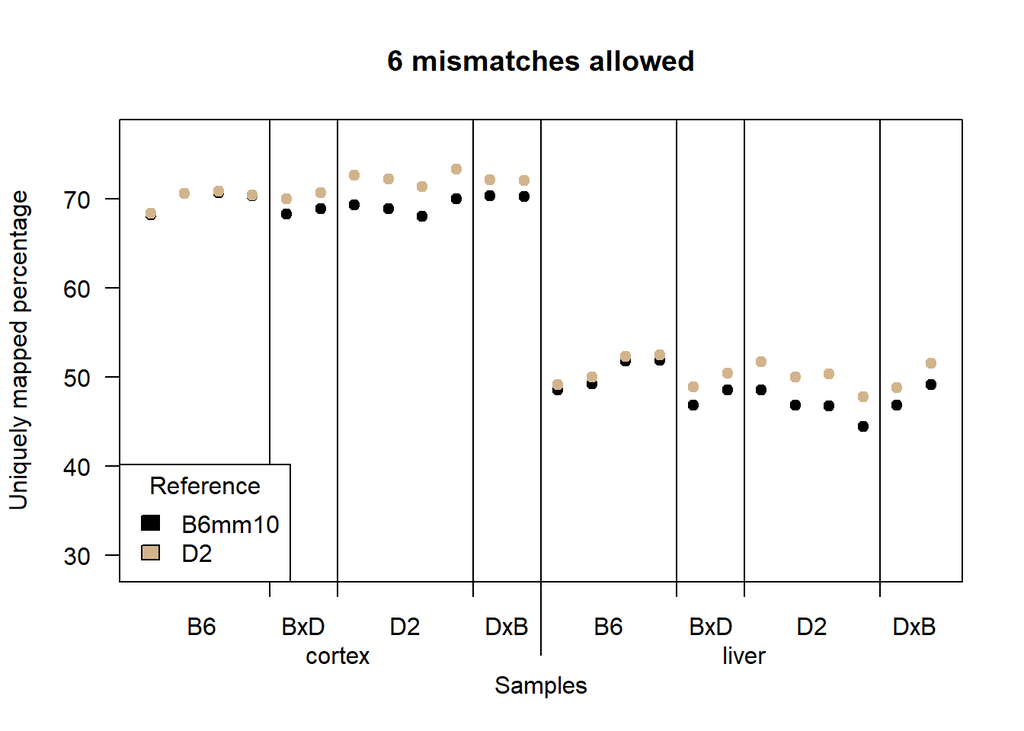

```r
# 6 mismatches allowed
plot(B6mm10$Uniq6, pch=19, col="black", ylim=c(29,77), las=2, xaxt="n", ylab="Uniquely mapped percentage", xlab="Samples", main="6 mismatches allowed")
points(D2$Uniq6, pch=19, col="tan")
abline(v=c(4.5,6.5,10.5,12.5,16.5,18.5,22.5))
axis(1, at=c(4.5,6.5,10.5,12.5,16.5,18.5,22.5), labels=rep(c(""),7))
axis(1, at=c(c(2.5,5.5,8.5,11.5),12+c(2.5,5.5,8.5,11.5)), tick=FALSE, labels=rep(c("B6","BxD","D2","DxB"),2))
for(myline in seq(0.5,2,0.5)){
  axis(1, at=12.5, line=myline, labels=c(""))
}
axis(1, at=c(6.5,18.5), line=1, tick=FALSE, labels=c("cortex", "liver"))
legend("bottomleft", title="Reference", legend=c("B6mm10","D2"), fill=c("black","tan"))
```

At 6 mismatches allowed, all these samples seem to map better on D2 reference.

### 10

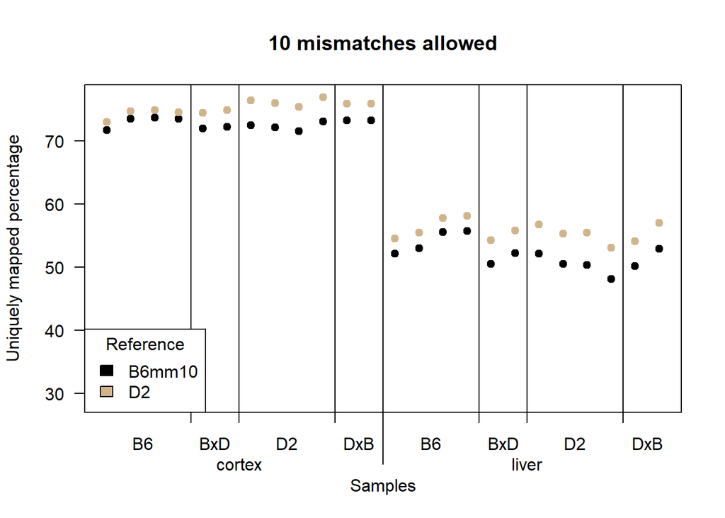

```r
# 10 mismatches allowed
plot(B6mm10$Uniq10, pch=19, col="black", ylim=c(29,77), las=2, xaxt="n", ylab="Uniquely mapped percentage", xlab="Samples", main="10 mismatches allowed")
points(D2$Uniq10, pch=19, col="tan")
abline(v=c(4.5,6.5,10.5,12.5,16.5,18.5,22.5))
axis(1, at=c(4.5,6.5,10.5,12.5,16.5,18.5,22.5), labels=rep(c(""),7))
axis(1, at=c(c(2.5,5.5,8.5,11.5),12+c(2.5,5.5,8.5,11.5)), tick=FALSE, labels=rep(c("B6","BxD","D2","DxB"),2))
for(myline in seq(0.5,2,0.5)){
  axis(1, at=12.5, line=myline, labels=c(""))
}
axis(1, at=c(6.5,18.5), line=1, tick=FALSE, labels=c("cortex", "liver"))
legend("bottomleft", title="Reference", legend=c("B6mm10","D2"), fill=c("black","tan"))
```

At 10 mismatches (maximum allowed by STAR default parameters), bias for D2 reference (similar to what observed previously on transcriptome).

## All samples

### 0

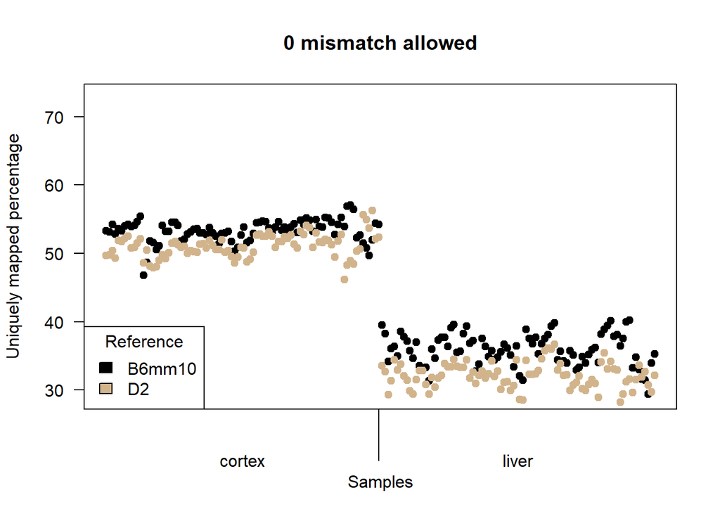

```r
# exactly matching
plot(B6mm10all$Uniq0, pch=19, col="black", ylim=c(29,73), las=2, xaxt="n", ylab="Uniquely mapped percentage", xlab="Samples", main="0 mismatch allowed")
points(D2all$Uniq0, pch=19, col="tan")
##abline(v=c(4.5,6.5,10.5,12.5,16.5,18.5,22.5))
##axis(1, at=c(4.5,6.5,10.5,12.5,16.5,18.5,22.5), labels=rep(c(""),7))
##axis(1, at=c(c(2.5,5.5,8.5,11.5),12+c(2.5,5.5,8.5,11.5)), tick=FALSE, labels=rep(c("B6","BxD","D2","DxB"),2))
for(myline in seq(0,2,0.5)){
  axis(1, at=88, line=myline, labels=c(""))
}
axis(1, at=c(44.5,132.5), line=1, tick=FALSE, labels=c("cortex", "liver"))
legend("bottomleft", title="Reference", legend=c("B6mm10","D2"), fill=c("black","tan"))
```

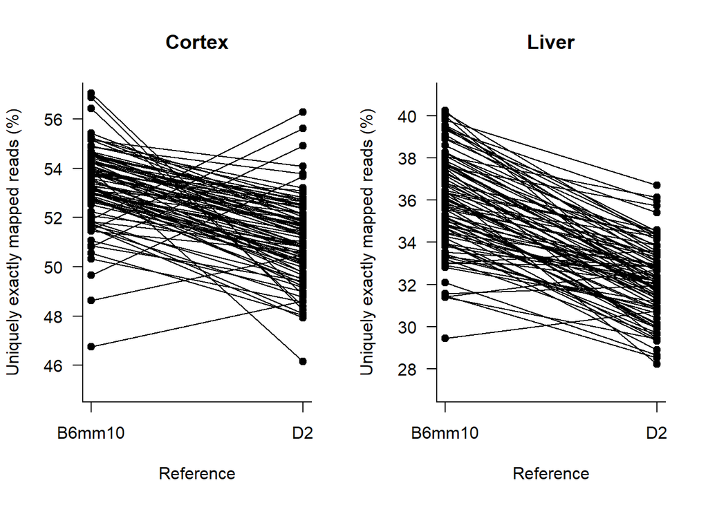

```r
# Difference in mappability by reference for uniquely exactly mapped reads
par(mfrow=c(1,2))

# in cortex
plot("", las=2, xlim=c(1,2), ylim=c(45,57), bty="l", xaxt="n", main="Cortex", xlab="Reference", ylab="Uniquely exactly mapped reads (%)")
axis(1, at=1:2, labels=c("B6mm10","D2"))
segments(x0=rep(2,176), y0=D2all[,"Uniq0"], x1=rep(1,176), y1=B6mm10all[,"Uniq0"],
         lty = par("lty"), lwd = par("lwd"))
points(rep(1,176),B6mm10all[,"Uniq0"], pch=19, cex=1)
points(rep(2,176),D2all[,"Uniq0"], pch=19, cex=1)

# in liver
plot("", las=2, xlim=c(1,2), ylim=c(27,41), bty="l", xaxt="n", main="Liver", xlab="Reference", ylab="Uniquely exactly mapped reads (%)")
axis(1, at=1:2, labels=c("B6mm10","D2"))
segments(x0=rep(2,176), y0=D2all[,"Uniq0"], x1=rep(1,176), y1=B6mm10all[,"Uniq0"],
         lty=par("lty"), lwd=1)
points(rep(1,176),B6mm10all[,"Uniq0"], pch=19, cex=1)
points(rep(2,176),D2all[,"Uniq0"], pch=19, cex=1)
```

### 1

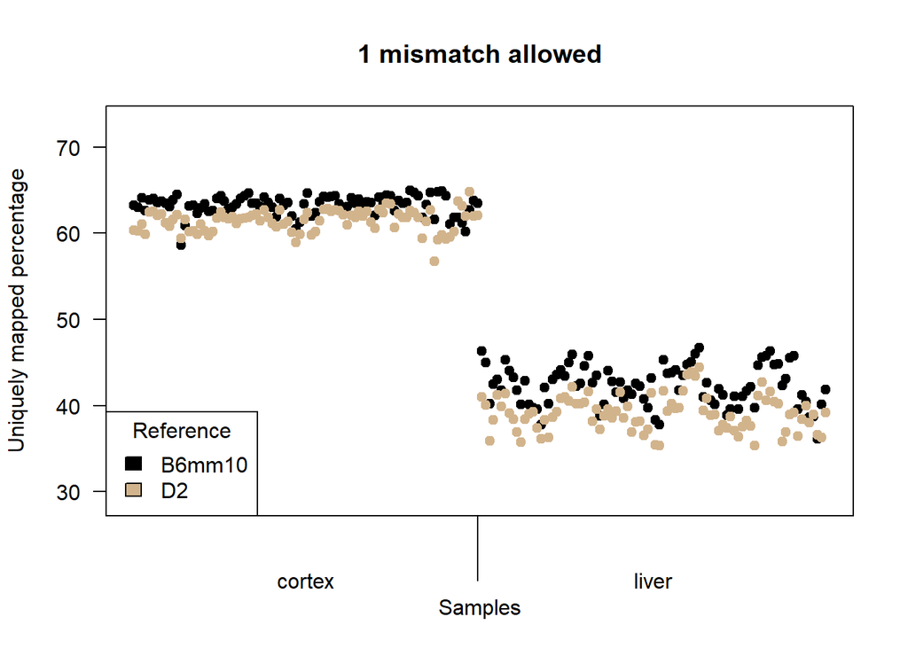

```r
# 1 mismatch allowed
plot(B6mm10all$Uniq1, pch=19, col="black", ylim=c(29,73), las=2, xaxt="n", ylab="Uniquely mapped percentage", xlab="Samples", main="1 mismatch allowed")
points(D2all$Uniq1, pch=19, col="tan")
for(myline in seq(0,2,0.5)){
  axis(1, at=88, line=myline, labels=c(""))
}
axis(1, at=c(44.5,132.5), line=1, tick=FALSE, labels=c("cortex", "liver"))
legend("bottomleft", title="Reference", legend=c("B6mm10","D2"), fill=c("black","tan"))
```

### 2

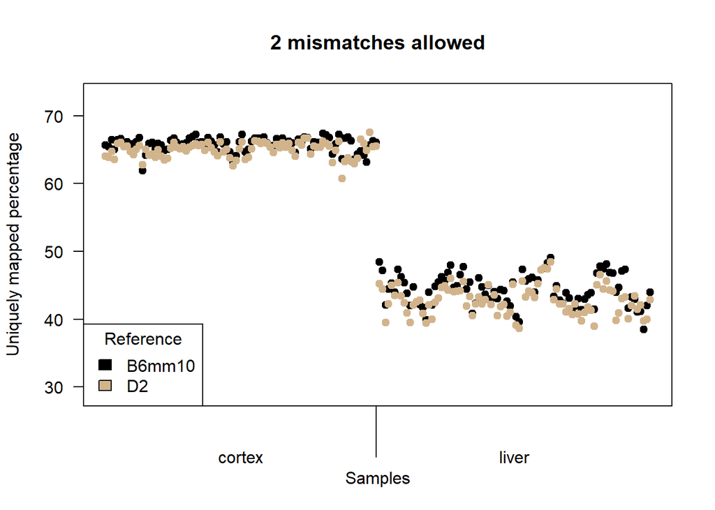

```r
# 2 mismatches allowed
plot(B6mm10all$Uniq2, pch=19, col="black", ylim=c(29,73), las=2, xaxt="n", ylab="Uniquely mapped percentage", xlab="Samples", main="2 mismatches allowed")
points(D2all$Uniq2, pch=19, col="tan")
for(myline in seq(0,2,0.5)){
  axis(1, at=88, line=myline, labels=c(""))
}
axis(1, at=c(44.5,132.5), line=1, tick=FALSE, labels=c("cortex", "liver"))
legend("bottomleft", title="Reference", legend=c("B6mm10","D2"), fill=c("black","tan"))
```

### 3

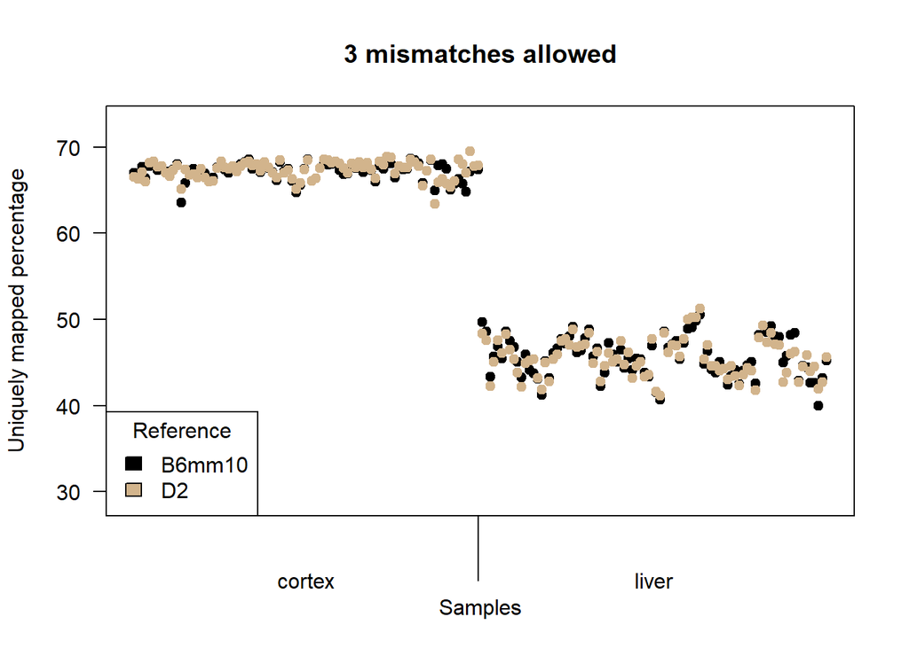

```r
# 3 mismatches allowed
plot(B6mm10all$Uniq3, pch=19, col="black", ylim=c(29,73), las=2, xaxt="n", ylab="Uniquely mapped percentage", xlab="Samples", main="3 mismatches allowed")
points(D2all$Uniq3, pch=19, col="tan")
for(myline in seq(0,2,0.5)){
  axis(1, at=88, line=myline, labels=c(""))
}
axis(1, at=c(44.5,132.5), line=1, tick=FALSE, labels=c("cortex", "liver"))
legend("bottomleft", title="Reference", legend=c("B6mm10","D2"), fill=c("black","tan"))
```

### 4

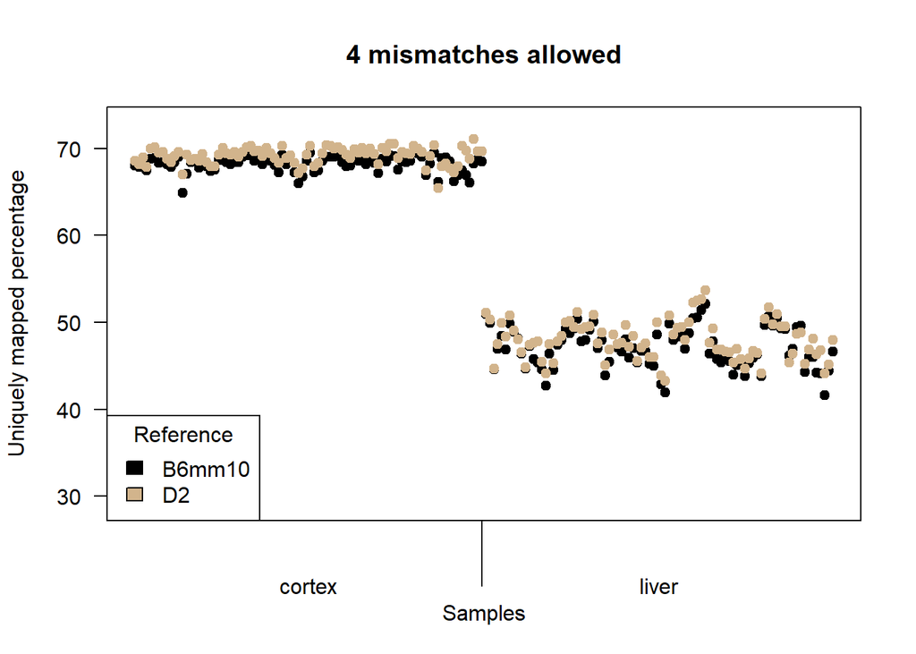

```r
# 4 mismatches allowed
plot(B6mm10all$Uniq4, pch=19, col="black", ylim=c(29,73), las=2, xaxt="n", ylab="Uniquely mapped percentage", xlab="Samples", main="4 mismatches allowed")
points(D2all$Uniq4, pch=19, col="tan")
for(myline in seq(0,2,0.5)){
  axis(1, at=88, line=myline, labels=c(""))
}
axis(1, at=c(44.5,132.5), line=1, tick=FALSE, labels=c("cortex", "liver"))
legend("bottomleft", title="Reference", legend=c("B6mm10","D2"), fill=c("black","tan"))
```

### 5

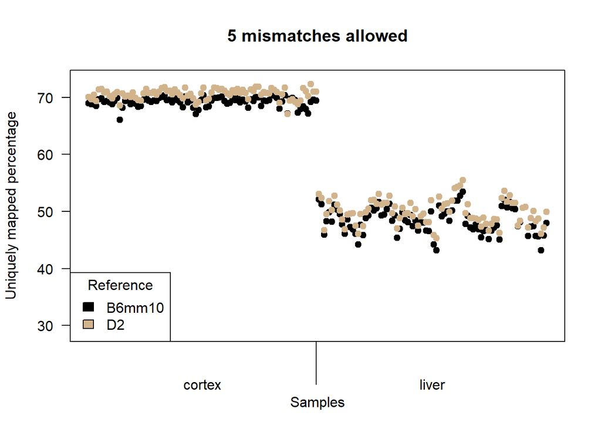

```r
# 5 mismatches allowed
plot(B6mm10all$Uniq5, pch=19, col="black", ylim=c(29,73), las=2, xaxt="n", ylab="Uniquely mapped percentage", xlab="Samples", main="5 mismatches allowed")
points(D2all$Uniq5, pch=19, col="tan")
for(myline in seq(0,2,0.5)){
  axis(1, at=88, line=myline, labels=c(""))
}
axis(1, at=c(44.5,132.5), line=1, tick=FALSE, labels=c("cortex", "liver"))
legend("bottomleft", title="Reference", legend=c("B6mm10","D2"), fill=c("black","tan"))
```

## By sample

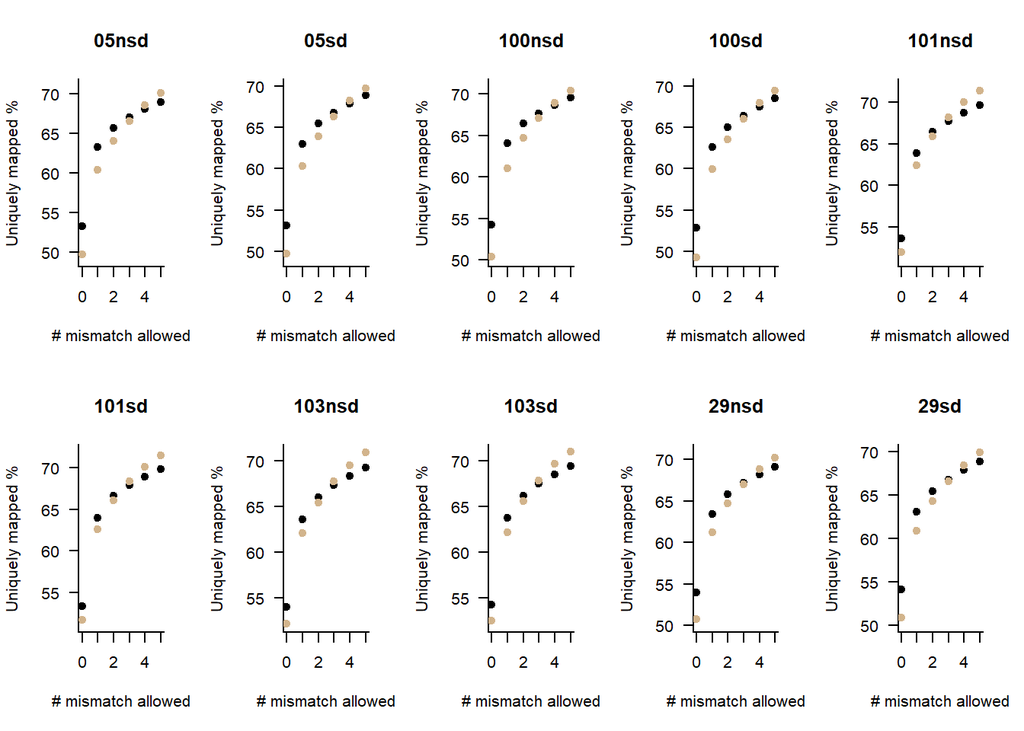

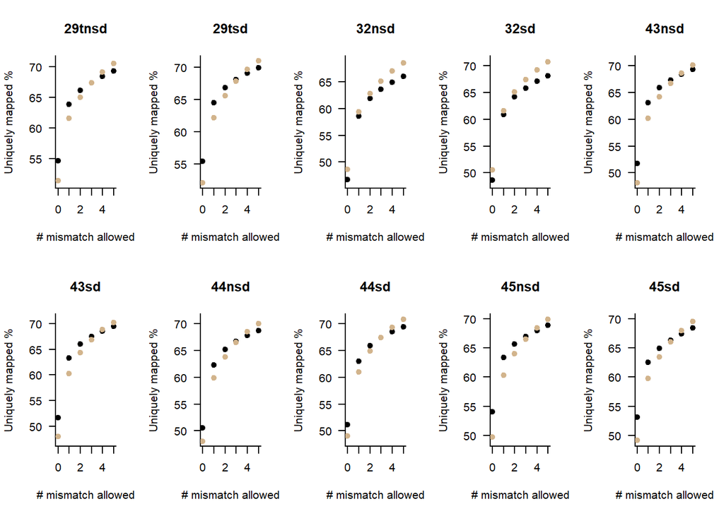

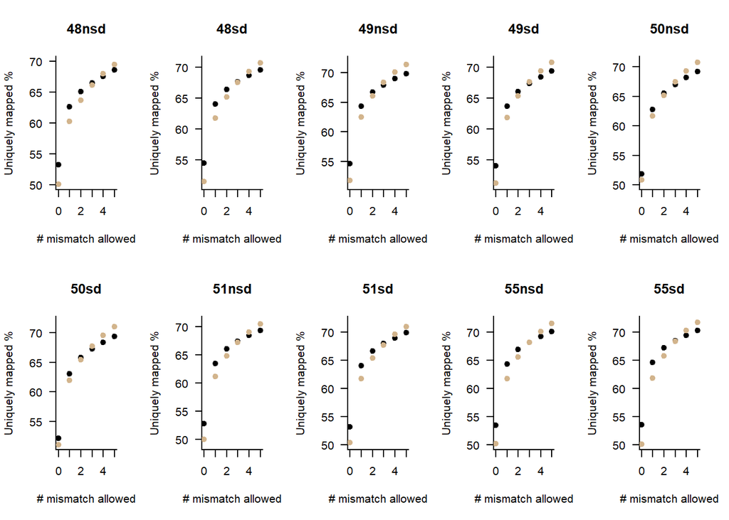

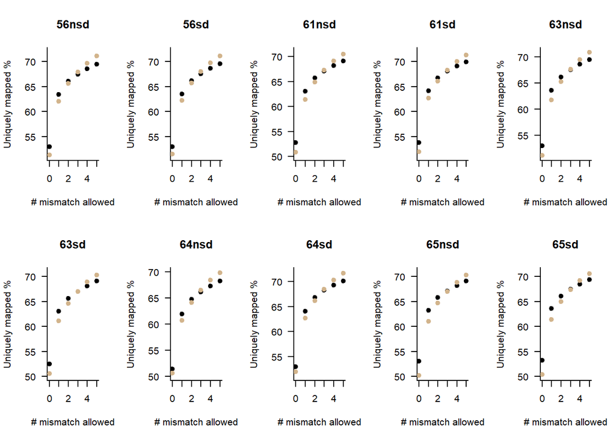

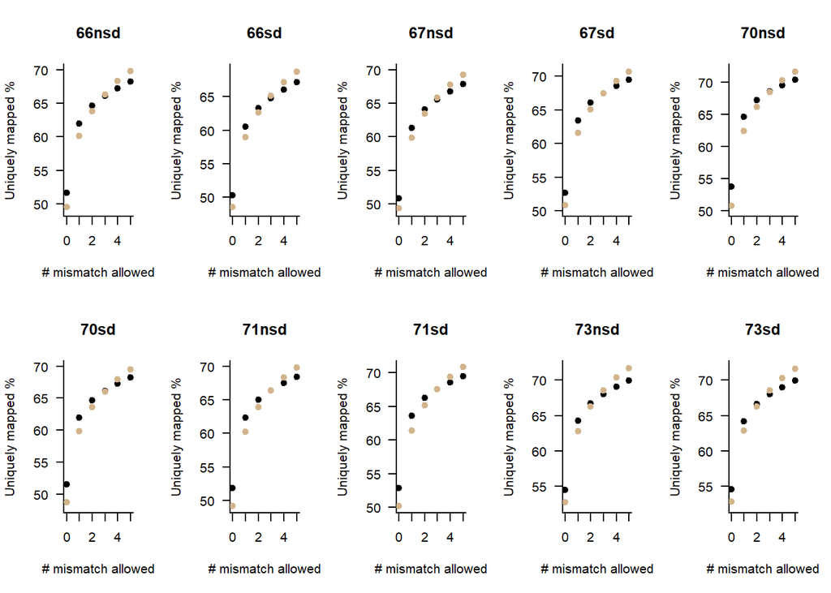

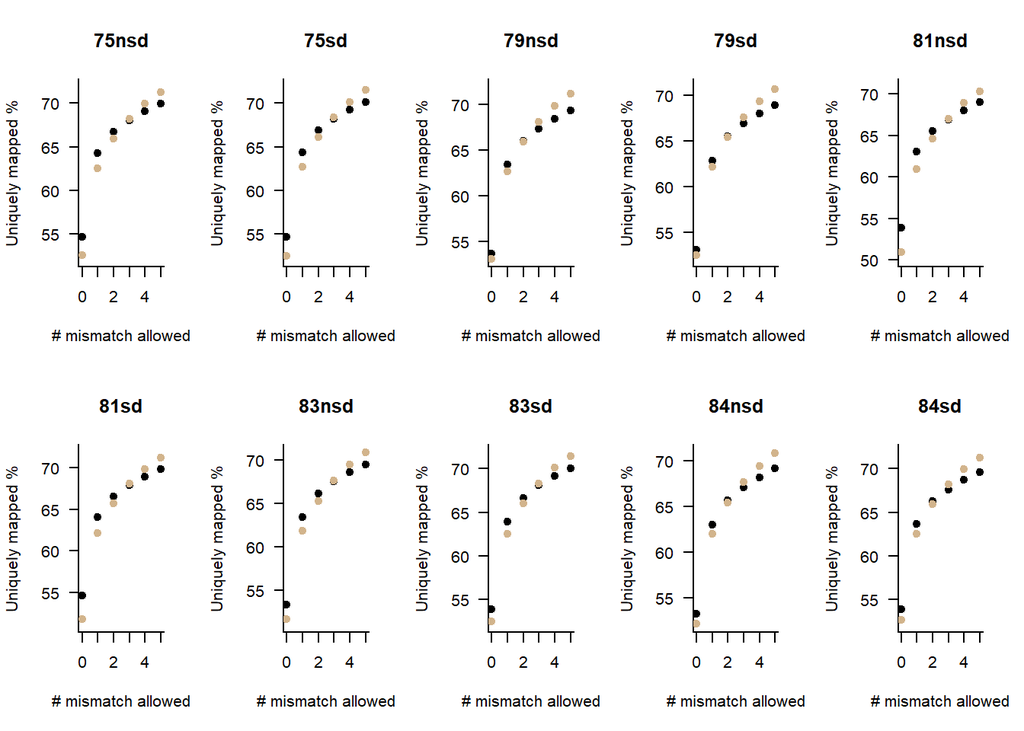

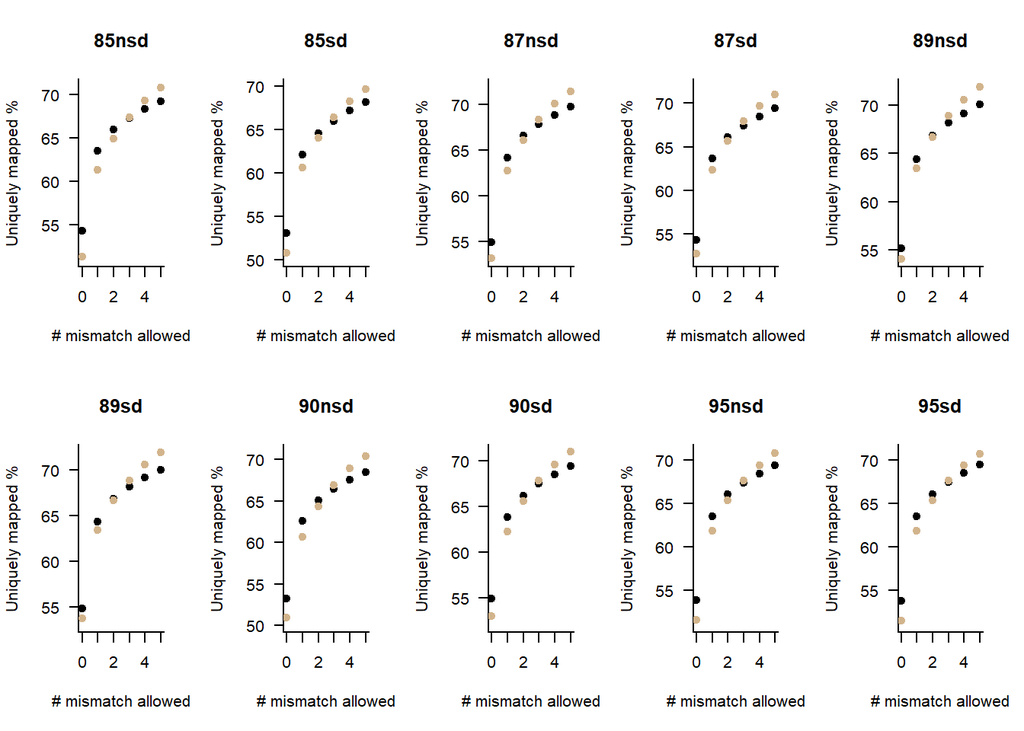

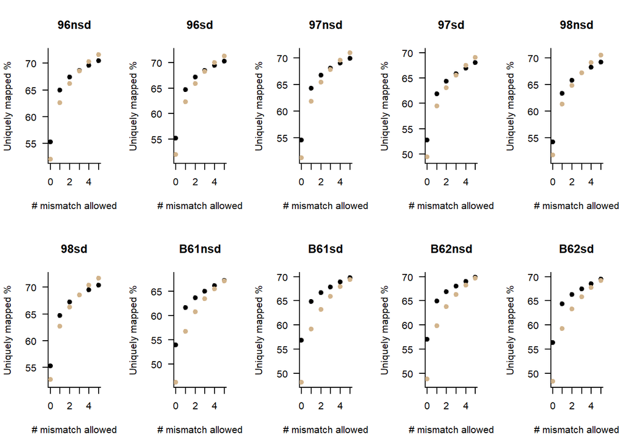

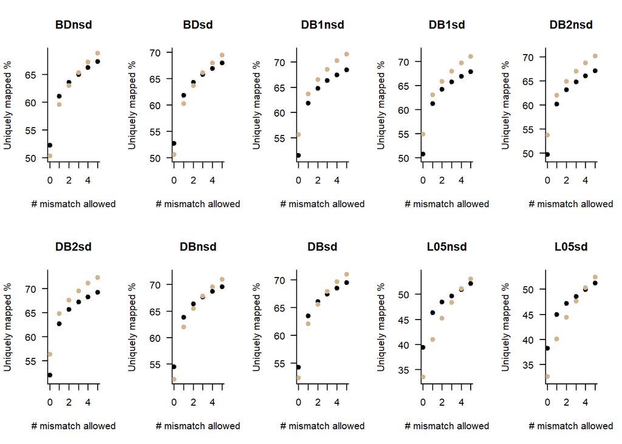

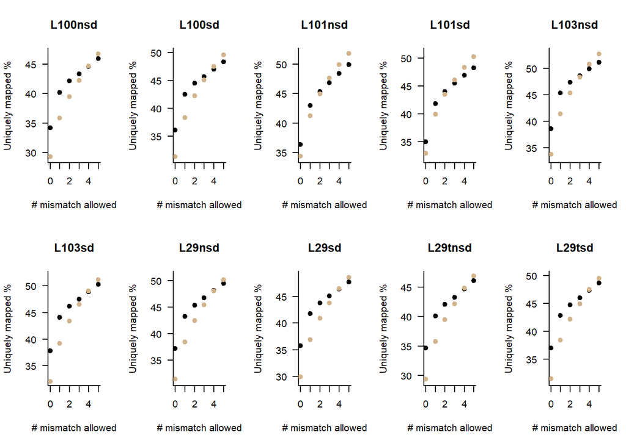

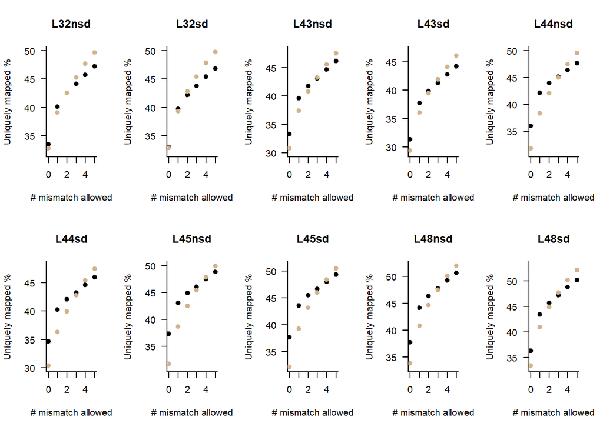

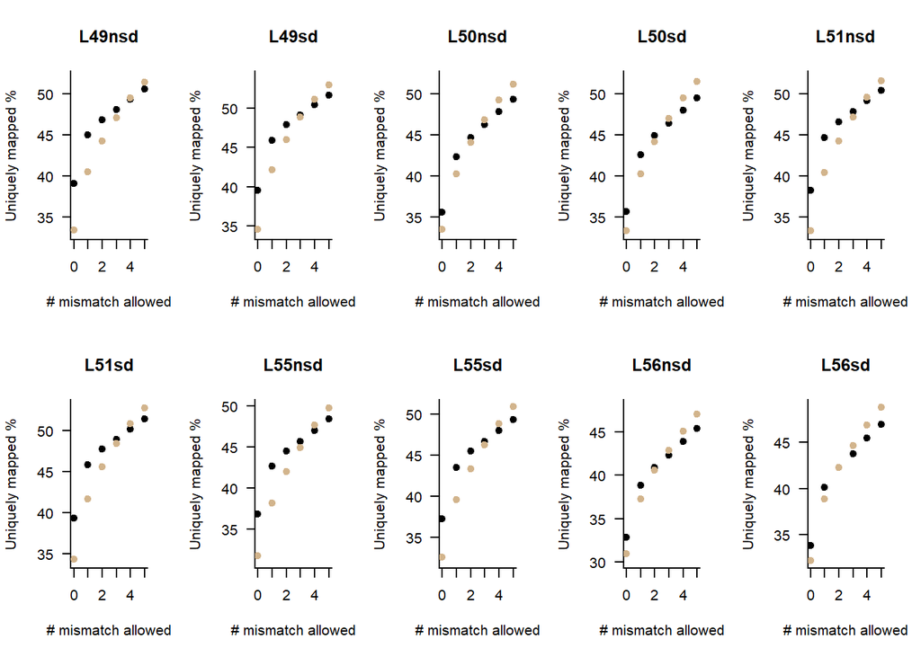

[6 more figures not shown]

```r
# comparison number of mismatch allowed for each sample
##par(mfcol=c(2,5))
##for(mysample in rownames(B6mm10all)){
  # on B6 mm10 reference
##  plot(c(0:5),B6mm10all[mysample,], las=1, bty="l", pch=19, ylim=c(0,75), xlab="# mismatch allowed", ylab="Uniquely mapped % on B6 mm10", main=mysample)
  # on D2 reference
##  plot(c(0:5),D2all[mysample,], las=1, bty="l", pch=19, col="tan", ylim=c(0,75), xlab="# mismatch allowed", ylab="Uniquely mapped % on D2", main=mysample)
##}

par(mfrow=c(2,5))
for(mysample in rownames(B6mm10all)){
  # on B6 mm10 reference
  plot(c(0:5),B6mm10all[mysample,], las=1, bty="l", pch=19, ylim=c(floor(min(B6mm10all[mysample,],D2all[mysample,])),ceiling(max(B6mm10all[mysample,],D2all[mysample,]))), xlab="# mismatch allowed", ylab="Uniquely mapped %", main=mysample)
  # on D2 reference
  points(c(0:5),D2all[mysample,], las=1, bty="l", pch=19, col="tan")
}
```

Uniquely mapped percentage always increases with higher number of mismatch allowed. D2 vs B6? liver vs cortex? Shape of increase???

## Genomic regions

Which genomic regions are of interest? Are there a lot of reads mapping between genes?

Use regions with higher coverage (window size? threshold?) and see if they intersect with gene annotation or not.

# Testing chromosomes to include

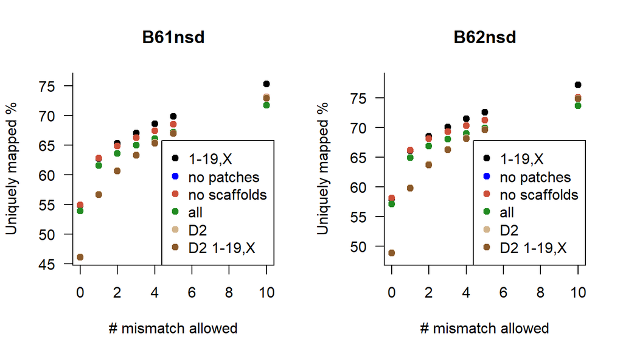

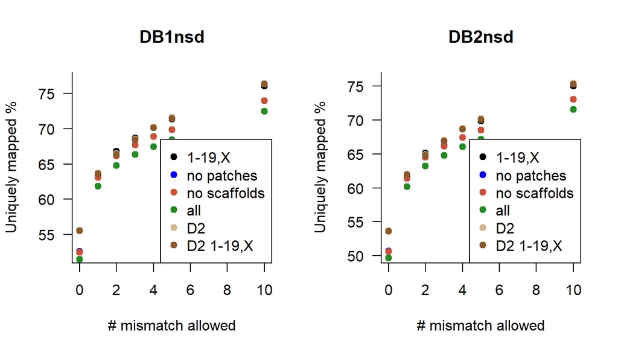

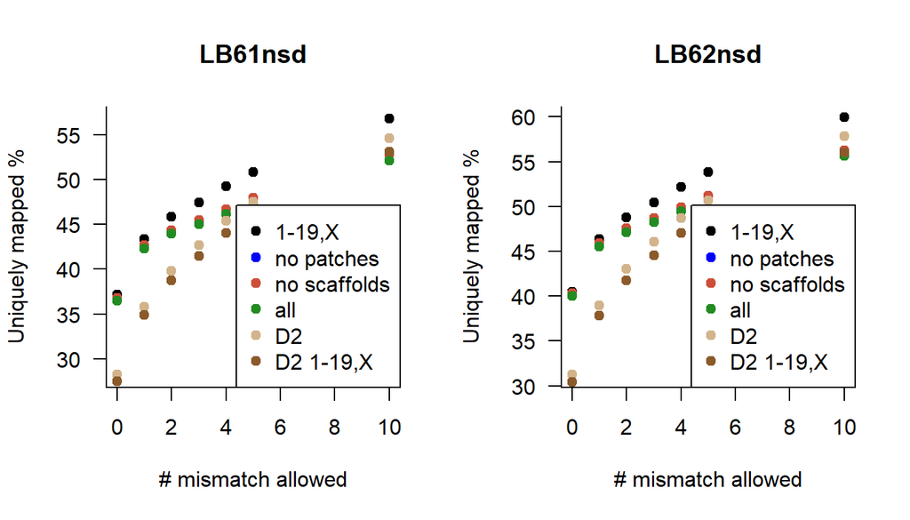

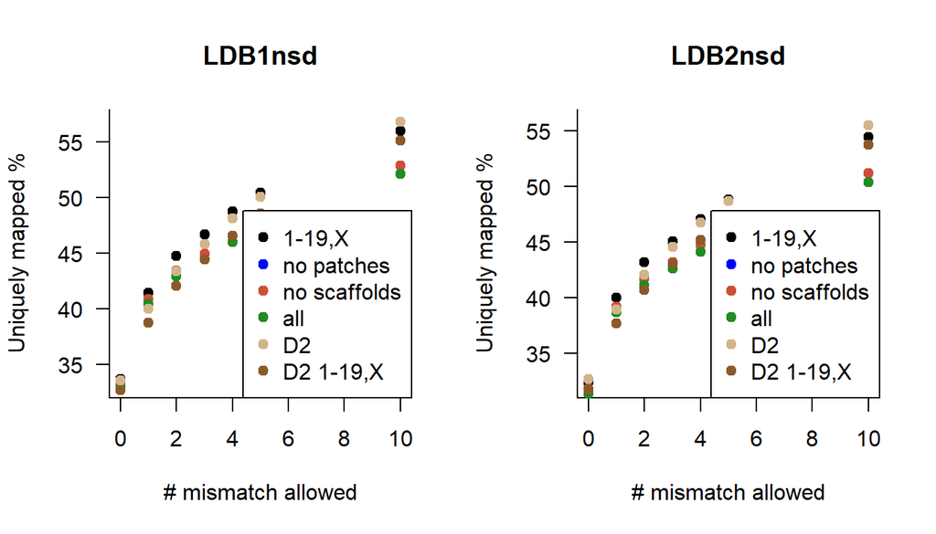

```r
par(mfrow=c(1,2))
for(mysample in rownames(B6mm10majorchromosomes)){
  # on B6 mm10 reference
  plot(c(0:5,10),B6mm10majorchromosomes[mysample,c("Uniq0","Uniq1","Uniq2","Uniq3","Uniq4","Uniq5","Uniq10")], las=1, bty="l", pch=19, ylim=c(floor(min(B6mm10majorchromosomes[mysample,c("Uniq0","Uniq1","Uniq2","Uniq3","Uniq4","Uniq5","Uniq10")],D2[mysample,c("Uniq0","Uniq1","Uniq2","Uniq3","Uniq4","Uniq5","Uniq10")])),ceiling(max(B6mm10majorchromosomes[mysample,c("Uniq0","Uniq1","Uniq2","Uniq3","Uniq4","Uniq5","Uniq10")],D2[mysample,c("Uniq0","Uniq1","Uniq2","Uniq3","Uniq4","Uniq5","Uniq10")]))), xlab="# mismatch allowed", ylab="Uniquely mapped %", main=mysample)
  # on
  points(c(0:5,10),B6mm10primaryassembly[mysample,c("Uniq0","Uniq1","Uniq2","Uniq3","Uniq4","Uniq5","Uniq10")], las=1, bty="l", pch=19, col="blue")
  points(c(0:5,10),B6mm10primaryassemblynoscaffolds[mysample,c("Uniq0","Uniq1","Uniq2","Uniq3","Uniq4","Uniq5","Uniq10")], las=1, bty="l", pch=19, col="tomato3")
  points(c(0:5,10),B6mm10[mysample,c("Uniq0","Uniq1","Uniq2","Uniq3","Uniq4","Uniq5","Uniq10")], las=1, bty="l", pch=19, col="forestgreen")
    # on D2 reference
  points(c(0:5,10),D2[mysample,c("Uniq0","Uniq1","Uniq2","Uniq3","Uniq4","Uniq5","Uniq10")], las=1, bty="l", pch=19, col="tan")
  points(c(0:5,10),D2majorchromosomes[mysample,c("Uniq0","Uniq1","Uniq2","Uniq3","Uniq4","Uniq5","Uniq10")], las=1, bty="l", pch=19, col="tan4")
  legend("bottomright", legend=c("1-19,X", "no patches", "no scaffolds", "all", "D2", "D2 1-19,X"), pch=19, col=c("black", "blue", "tomato3", "forestgreen", "tan", "tan4"), cex=1)
}
```

(Blue points are under red points.)

## all

Ever feature is allowed (if present): MT and Y chromosomes, scaffolds, patches

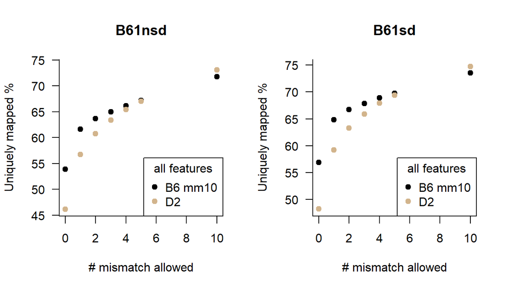

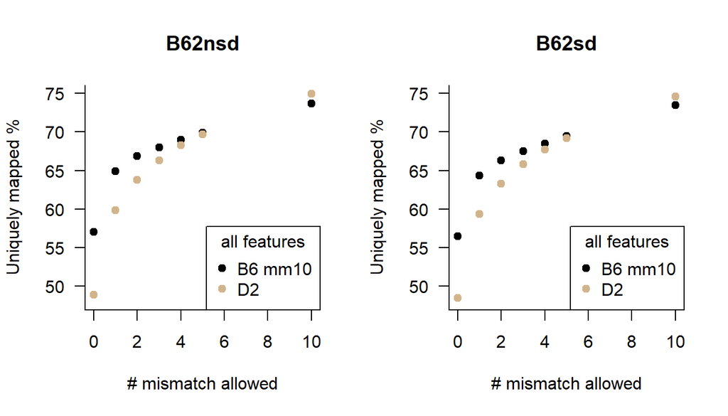

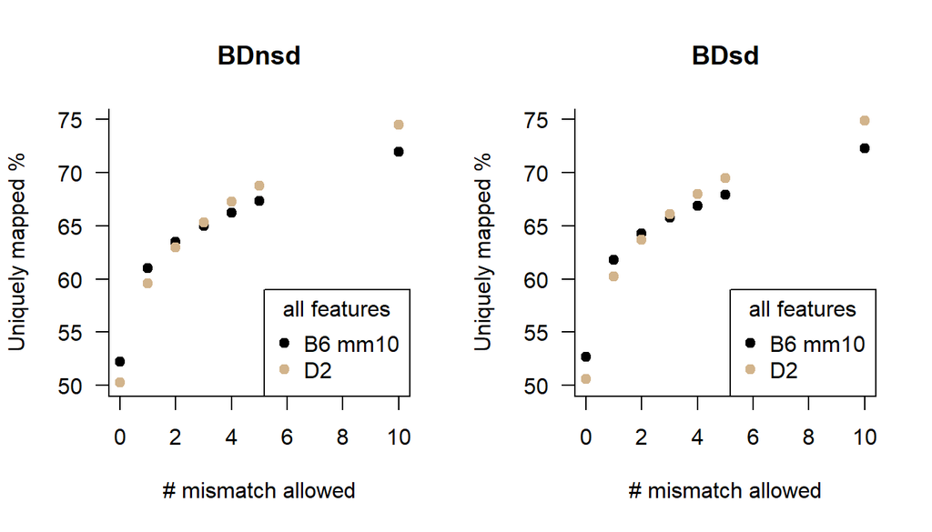

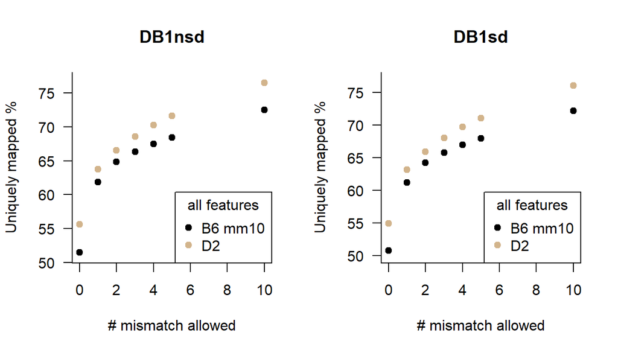

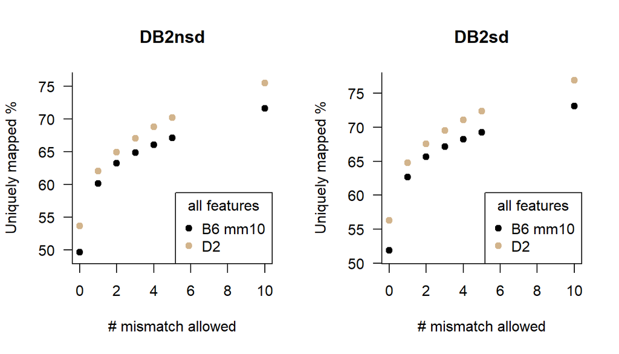

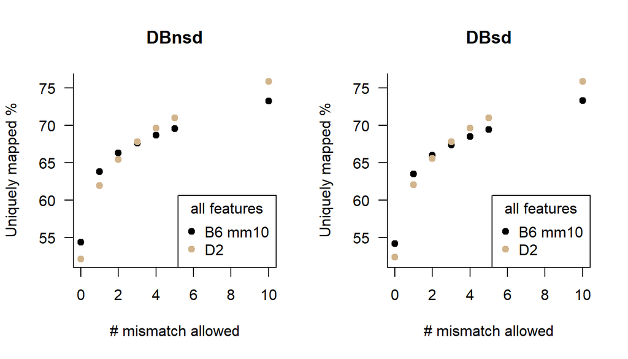

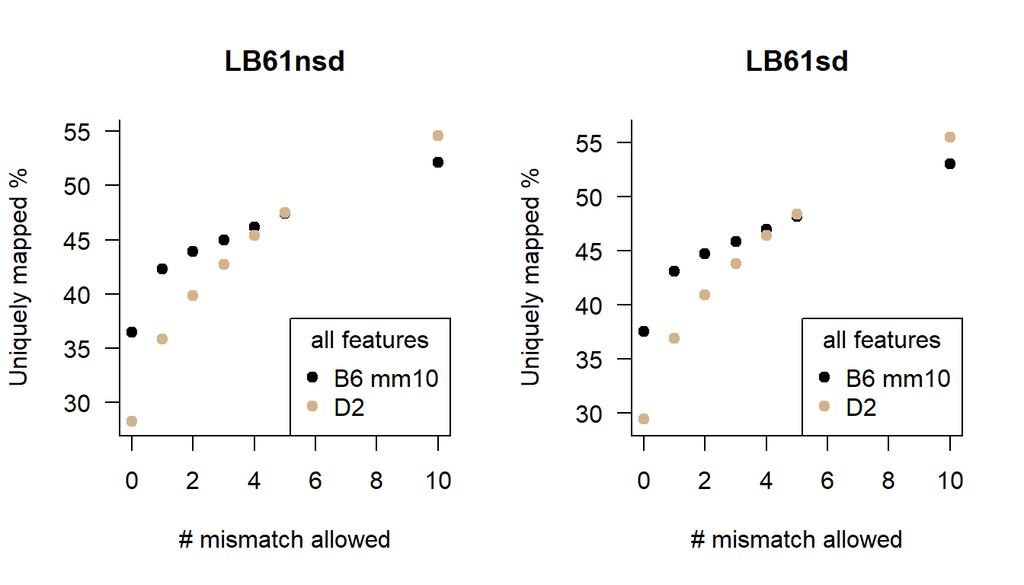

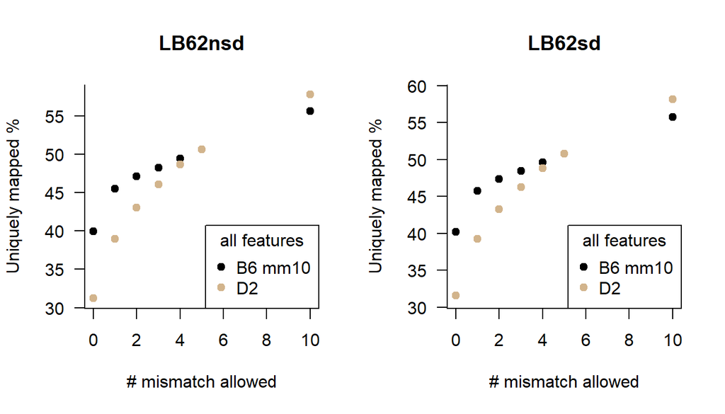

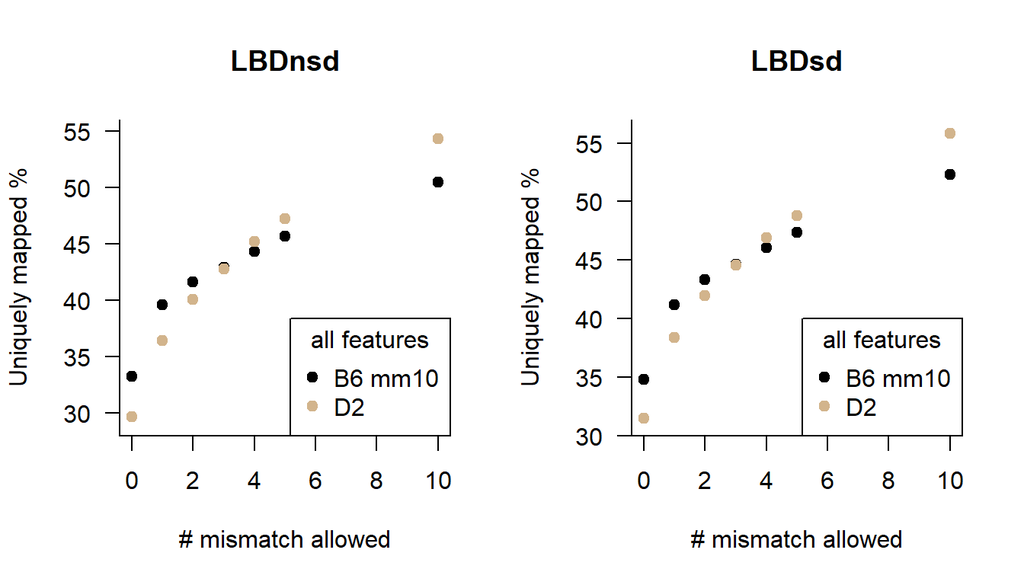

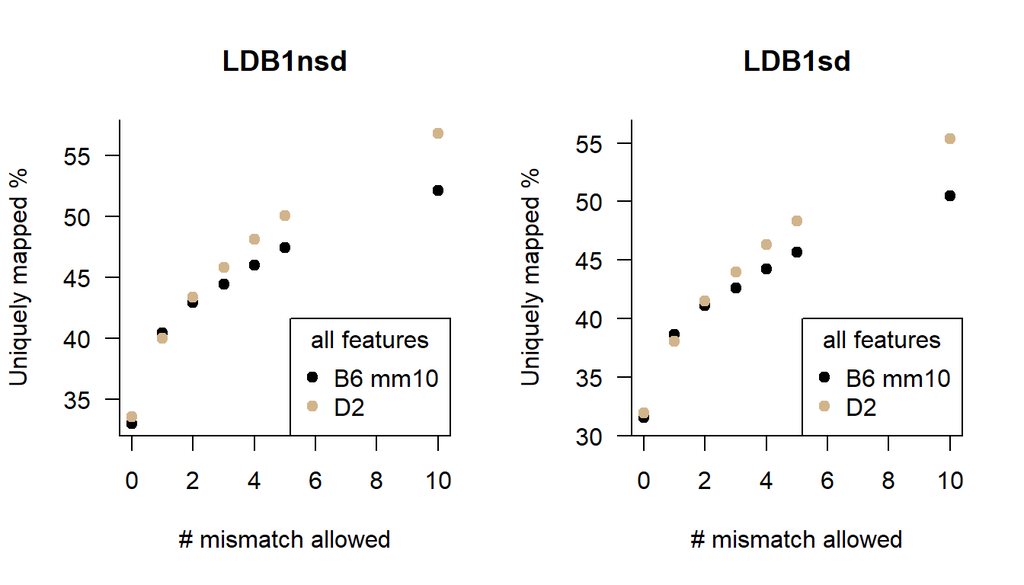

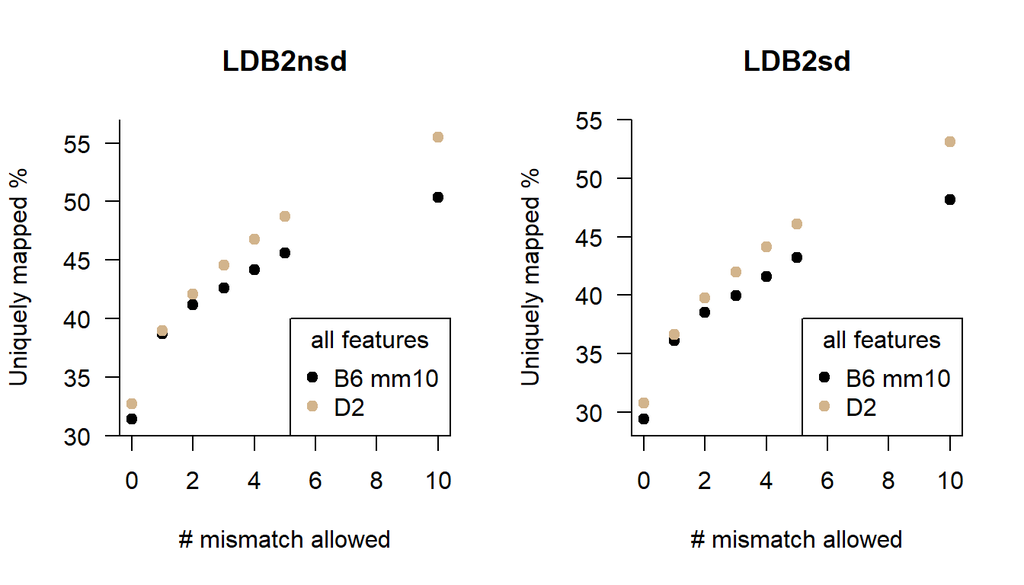

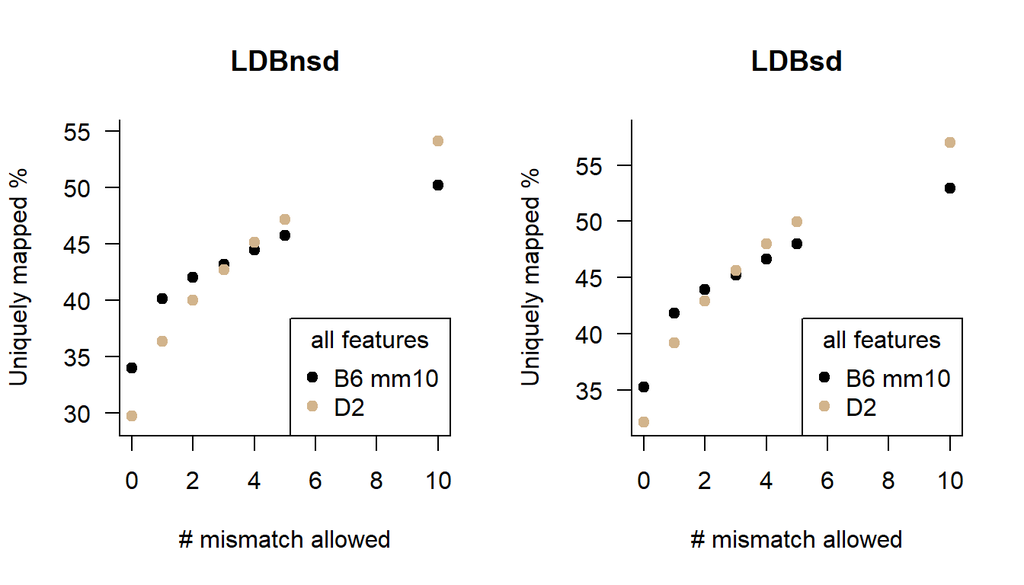

```r
par(mfrow=c(1,2))
for(mysample in rownames(B6mm10)){
  # on B6 mm10 reference
  plot(c(0:5,10),B6mm10[mysample,c("Uniq0","Uniq1","Uniq2","Uniq3","Uniq4","Uniq5","Uniq10")], las=1, bty="l", pch=19, ylim=c(floor(min(B6mm10[mysample,c("Uniq0","Uniq1","Uniq2","Uniq3","Uniq4","Uniq5","Uniq10")],D2[mysample,c("Uniq0","Uniq1","Uniq2","Uniq3","Uniq4","Uniq5","Uniq10")])),ceiling(max(B6mm10[mysample,c("Uniq0","Uniq1","Uniq2","Uniq3","Uniq4","Uniq5","Uniq10")],D2[mysample,c("Uniq0","Uniq1","Uniq2","Uniq3","Uniq4","Uniq5","Uniq10")]))), xlab="# mismatch allowed", ylab="Uniquely mapped %", main=mysample)
  points(c(0:5,10),D2[mysample,c("Uniq0","Uniq1","Uniq2","Uniq3","Uniq4","Uniq5","Uniq10")], las=1, bty="l", pch=19, col="tan")
  legend("bottomright", title="all features", legend=c("B6 mm10", "D2"), pch=19, col=c("black", "tan"), cex=1)
}
```

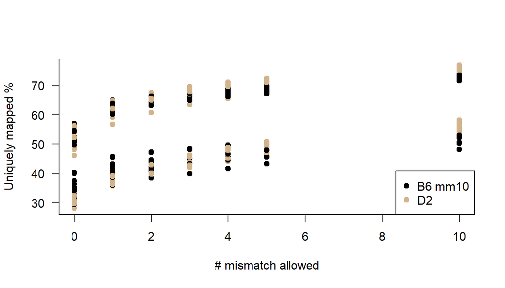

```r
# all samples in 1 graph
par(mfrow=c(1,1))
plot(x="",y="", las=1, bty="l", pch=19, xlim=c(0,10), ylim=c(floor(min(B6mm10[,c("Uniq0","Uniq1","Uniq2","Uniq3","Uniq4","Uniq5","Uniq10")],D2[,c("Uniq0","Uniq1","Uniq2","Uniq3","Uniq4","Uniq5","Uniq10")])),ceiling(max(B6mm10[,c("Uniq0","Uniq1","Uniq2","Uniq3","Uniq4","Uniq5","Uniq10")],D2[,c("Uniq0","Uniq1","Uniq2","Uniq3","Uniq4","Uniq5","Uniq10")]))), xlab="# mismatch allowed", ylab="Uniquely mapped %")
for(mysample in rownames(B6mm10)){
  # on B6 mm10 reference
  points(c(0:5,10),B6mm10[mysample,c("Uniq0","Uniq1","Uniq2","Uniq3","Uniq4","Uniq5","Uniq10")], pch=19)
  points(c(0:5,10),D2[mysample,c("Uniq0","Uniq1","Uniq2","Uniq3","Uniq4","Uniq5","Uniq10")], las=1, bty="l", pch=19, col="tan")
  legend("bottomright", legend=c("B6 mm10", "D2"), pch=19, col=c("black", "tan"), cex=1)
}
```

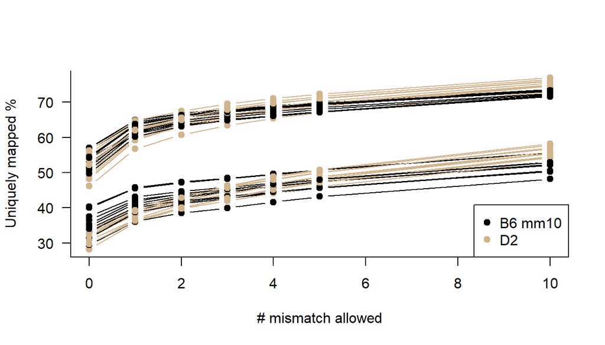

```r
# all samples in 1 graph with segments per sample
par(mfrow=c(1,1))
plot(x="",y="", las=1, bty="l", pch=19, xlim=c(0,10), ylim=c(floor(min(B6mm10[,c("Uniq0","Uniq1","Uniq2","Uniq3","Uniq4","Uniq5","Uniq10")],D2[,c("Uniq0","Uniq1","Uniq2","Uniq3","Uniq4","Uniq5","Uniq10")])),ceiling(max(B6mm10[,c("Uniq0","Uniq1","Uniq2","Uniq3","Uniq4","Uniq5","Uniq10")],D2[,c("Uniq0","Uniq1","Uniq2","Uniq3","Uniq4","Uniq5","Uniq10")]))), xlab="# mismatch allowed", ylab="Uniquely mapped %")
for(mysample in rownames(B6mm10)){
  # on B6 mm10 reference
  points(c(0:5,10),B6mm10[mysample,c("Uniq0","Uniq1","Uniq2","Uniq3","Uniq4","Uniq5","Uniq10")], type="b", pch=19)
  points(c(0:5,10),D2[mysample,c("Uniq0","Uniq1","Uniq2","Uniq3","Uniq4","Uniq5","Uniq10")], las=1, bty="l", type="b", pch=19, col="tan")
  legend("bottomright", legend=c("B6 mm10", "D2"), pch=19, col=c("black", "tan"), cex=1)
}
```

```r
# calculate diff reference-specific
CB6samples <- c("B61nsd", "B61sd", "B62nsd", "B62sd")
LB6samples <- c("LB61nsd", "LB61sd", "LB62nsd", "LB62sd")
CD2samples <- c("DB1nsd", "DB1sd", "DB2nsd", "DB2sd")
LD2samples <- c("LDB1nsd", "LDB1sd", "LDB2nsd", "LDB2sd")

mean(B6mm10[CB6samples,"Uniq0"]-D2[CB6samples,"Uniq0"])
```

```
## [1] 8.15
```

```r
mean(B6mm10[LB6samples,"Uniq0"]-D2[LB6samples,"Uniq0"])
```

```
## [1] 8.4325
```

```r
mean(D2[CD2samples,"Uniq0"]-B6mm10[CD2samples,"Uniq0"])
```

```
## [1] 4.15
```

```r
mean(D2[LD2samples,"Uniq0"]-B6mm10[LD2samples,"Uniq0"])
```

```
## [1] 0.89
```

## no patches

scaffolds, MT and Y chromosomes allowed

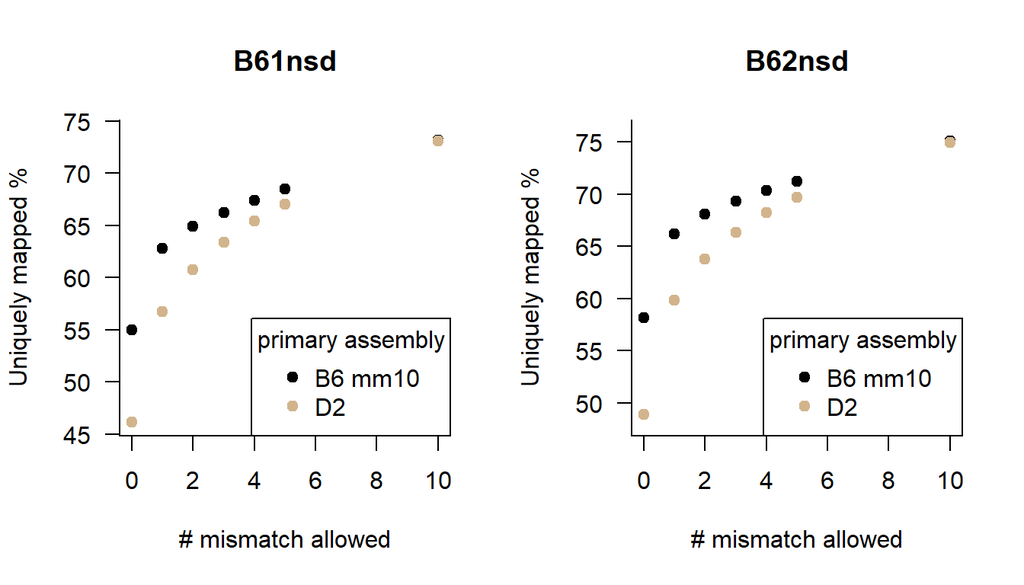

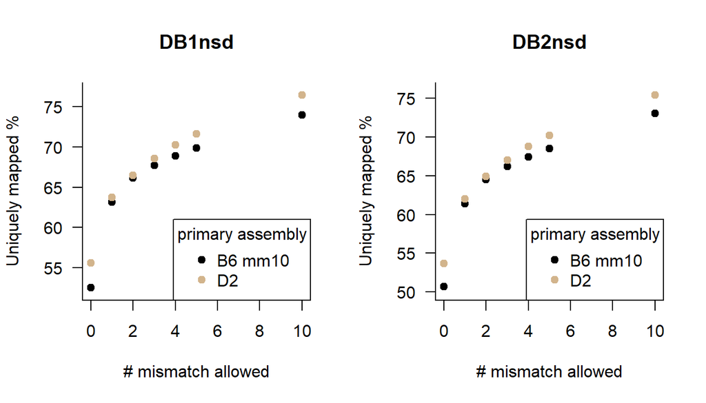

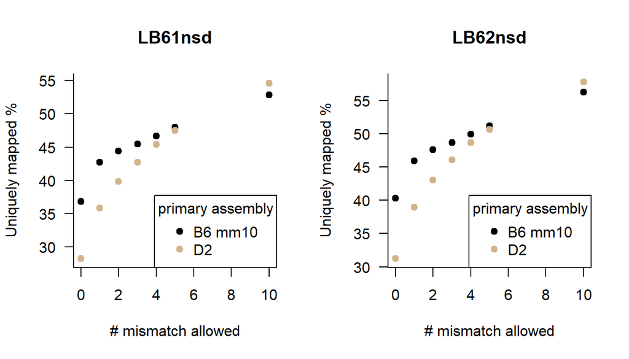

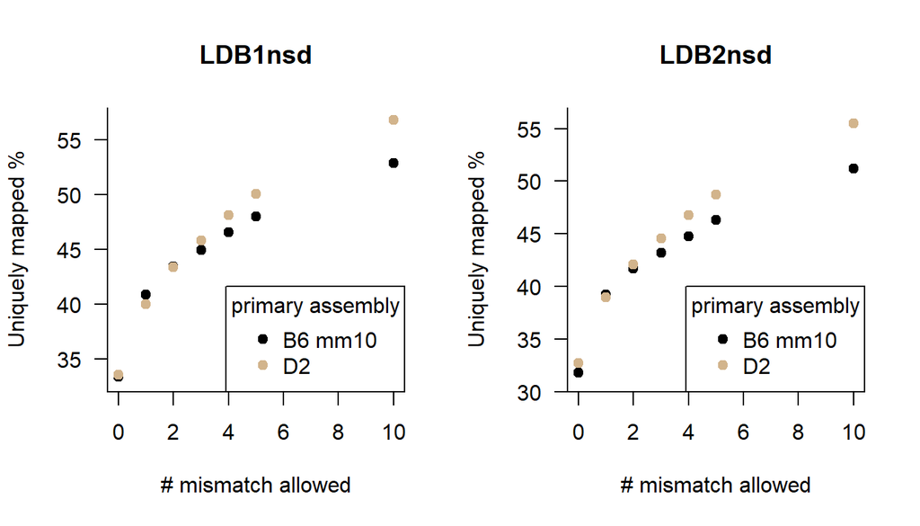

```r
par(mfrow=c(1,2))
for(mysample in rownames(B6mm10primaryassembly)){
  # on B6 mm10 reference
  plot(c(0:5,10),B6mm10primaryassembly[mysample,c("Uniq0","Uniq1","Uniq2","Uniq3","Uniq4","Uniq5","Uniq10")], las=1, bty="l", pch=19, ylim=c(floor(min(B6mm10primaryassembly[mysample,c("Uniq0","Uniq1","Uniq2","Uniq3","Uniq4","Uniq5","Uniq10")],D2[mysample,c("Uniq0","Uniq1","Uniq2","Uniq3","Uniq4","Uniq5","Uniq10")])),ceiling(max(B6mm10primaryassembly[mysample,c("Uniq0","Uniq1","Uniq2","Uniq3","Uniq4","Uniq5","Uniq10")],D2[mysample,c("Uniq0","Uniq1","Uniq2","Uniq3","Uniq4","Uniq5","Uniq10")]))), xlab="# mismatch allowed", ylab="Uniquely mapped %", main=mysample)
  points(c(0:5,10),D2[mysample,c("Uniq0","Uniq1","Uniq2","Uniq3","Uniq4","Uniq5","Uniq10")], las=1, bty="l", pch=19, col="tan")
  legend("bottomright", title="primary assembly", legend=c("B6 mm10", "D2"), pch=19, col=c("black", "tan"), cex=1)
}
```

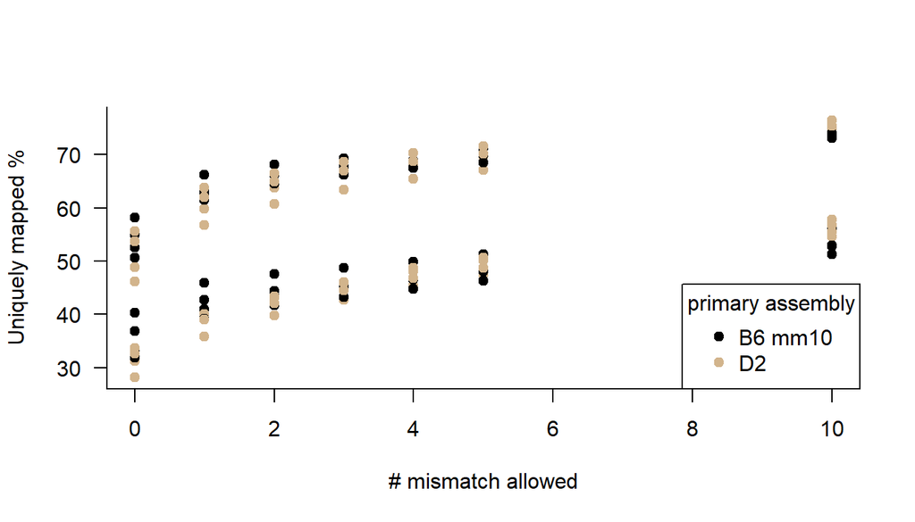

```r
# all samples in 1 graph
par(mfrow=c(1,1))
plot(x="",y="", las=1, bty="l", pch=19, xlim=c(0,10), ylim=c(floor(min(B6mm10primaryassembly[,c("Uniq0","Uniq1","Uniq2","Uniq3","Uniq4","Uniq5","Uniq10")],D2[,c("Uniq0","Uniq1","Uniq2","Uniq3","Uniq4","Uniq5","Uniq10")])),ceiling(max(B6mm10primaryassembly[,c("Uniq0","Uniq1","Uniq2","Uniq3","Uniq4","Uniq5","Uniq10")],D2[,c("Uniq0","Uniq1","Uniq2","Uniq3","Uniq4","Uniq5","Uniq10")]))), xlab="# mismatch allowed", ylab="Uniquely mapped %")
for(mysample in rownames(B6mm10primaryassembly)){
  # on B6 mm10 reference
  points(c(0:5,10),B6mm10primaryassembly[mysample,c("Uniq0","Uniq1","Uniq2","Uniq3","Uniq4","Uniq5","Uniq10")], pch=19)
  points(c(0:5,10),D2[mysample,c("Uniq0","Uniq1","Uniq2","Uniq3","Uniq4","Uniq5","Uniq10")], las=1, bty="l", pch=19, col="tan")
  legend("bottomright", title="primary assembly", legend=c("B6 mm10", "D2"), pch=19, col=c("black", "tan"), cex=1)
}
```

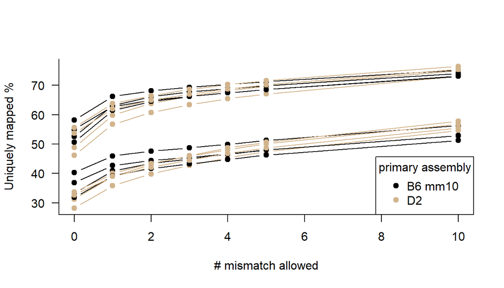

```r
# all samples in 1 graph with segments per sample
par(mfrow=c(1,1))
plot(x="",y="", las=1, bty="l", pch=19, xlim=c(0,10), ylim=c(floor(min(B6mm10primaryassembly[,c("Uniq0","Uniq1","Uniq2","Uniq3","Uniq4","Uniq5","Uniq10")],D2[,c("Uniq0","Uniq1","Uniq2","Uniq3","Uniq4","Uniq5","Uniq10")])),ceiling(max(B6mm10primaryassembly[,c("Uniq0","Uniq1","Uniq2","Uniq3","Uniq4","Uniq5","Uniq10")],D2[,c("Uniq0","Uniq1","Uniq2","Uniq3","Uniq4","Uniq5","Uniq10")]))), xlab="# mismatch allowed", ylab="Uniquely mapped %")
for(mysample in rownames(B6mm10primaryassembly)){
  # on B6 mm10 reference
  points(c(0:5,10),B6mm10primaryassembly[mysample,c("Uniq0","Uniq1","Uniq2","Uniq3","Uniq4","Uniq5","Uniq10")], type="b", pch=19)
  points(c(0:5,10),D2[mysample,c("Uniq0","Uniq1","Uniq2","Uniq3","Uniq4","Uniq5","Uniq10")], las=1, bty="l", type="b", pch=19, col="tan")
  legend("bottomright", title="primary assembly", legend=c("B6 mm10", "D2"), pch=19, col=c("black", "tan"), cex=1)
}
```

```r
# calculate diff reference-specific
CB6samples <- c("B61nsd", "B62nsd")
LB6samples <- c("LB61nsd", "LB62nsd")
CD2samples <- c("DB1nsd", "DB2nsd")
LD2samples <- c("LDB1nsd", "LDB2nsd")

mean(B6mm10primaryassembly[CB6samples,"Uniq0"]-D2[CB6samples,"Uniq0"])
```

```
## [1] 9.03
```

```r
mean(B6mm10primaryassembly[LB6samples,"Uniq0"]-D2[LB6samples,"Uniq0"])
```

```
## [1] 8.835
```

```r
mean(D2[CD2samples,"Uniq0"]-B6mm10primaryassembly[CD2samples,"Uniq0"])
```

```
## [1] 3.05
```

```r
mean(D2[LD2samples,"Uniq0"]-B6mm10primaryassembly[LD2samples,"Uniq0"])
```

```
## [1] 0.535
```

## major chromosomes

Considering only chromosomes 1 to 19 and X

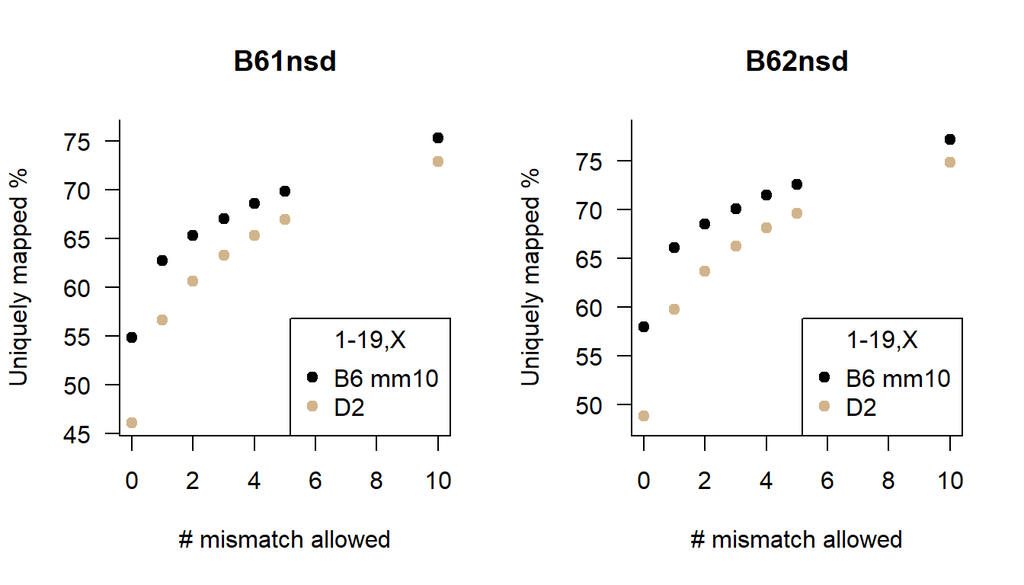

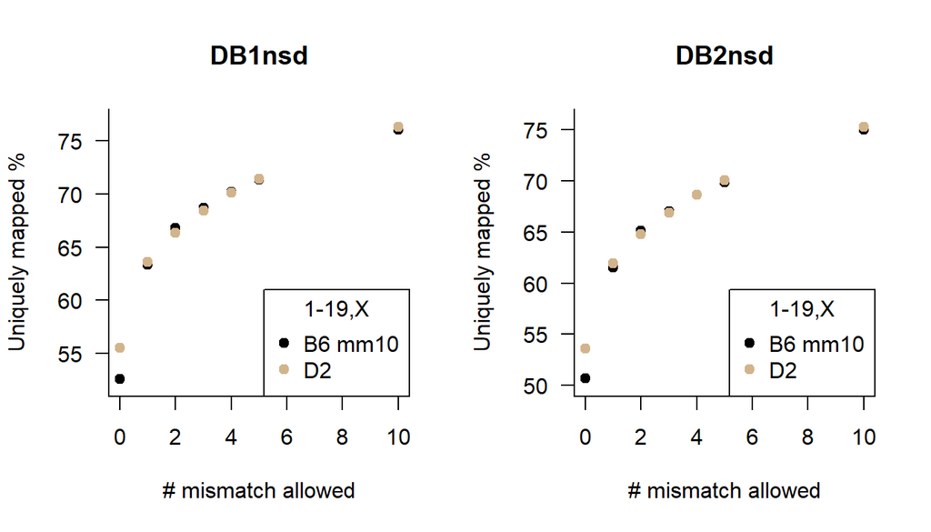

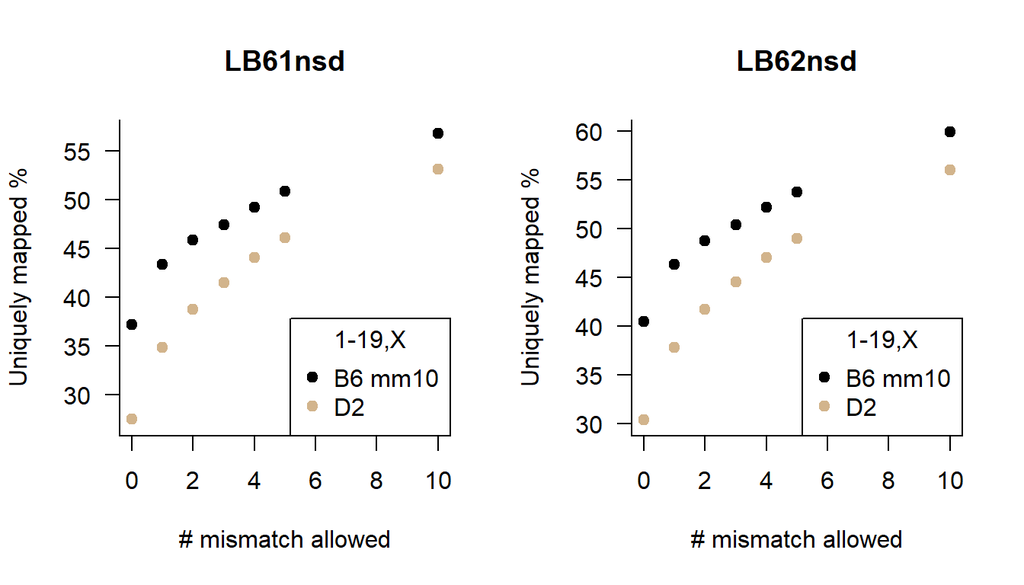

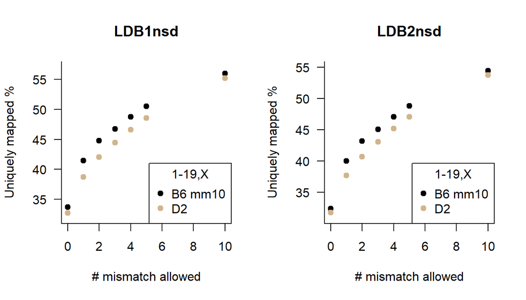

```r
par(mfrow=c(1,2))
for(mysample in rownames(B6mm10majorchromosomes)){
  # on B6 mm10 reference
  plot(c(0:5,10),B6mm10majorchromosomes[mysample,c("Uniq0","Uniq1","Uniq2","Uniq3","Uniq4","Uniq5","Uniq10")], las=1, bty="l", pch=19, ylim=c(floor(min(B6mm10majorchromosomes[mysample,c("Uniq0","Uniq1","Uniq2","Uniq3","Uniq4","Uniq5","Uniq10")],D2majorchromosomes[mysample,c("Uniq0","Uniq1","Uniq2","Uniq3","Uniq4","Uniq5","Uniq10")])),ceiling(max(B6mm10majorchromosomes[mysample,c("Uniq0","Uniq1","Uniq2","Uniq3","Uniq4","Uniq5","Uniq10")],D2majorchromosomes[mysample,c("Uniq0","Uniq1","Uniq2","Uniq3","Uniq4","Uniq5","Uniq10")]))), xlab="# mismatch allowed", ylab="Uniquely mapped %", main=mysample)
  points(c(0:5,10),D2majorchromosomes[mysample,c("Uniq0","Uniq1","Uniq2","Uniq3","Uniq4","Uniq5","Uniq10")], las=1, bty="l", pch=19, col="tan")
  legend("bottomright", title="1-19,X", legend=c("B6 mm10", "D2"), pch=19, col=c("black", "tan"), cex=1)
}
```

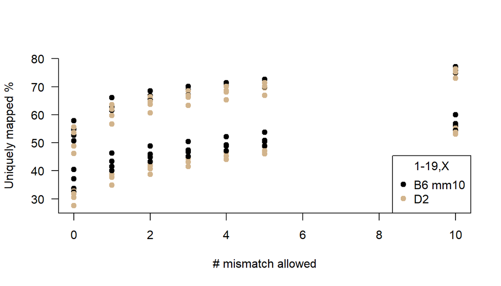

```r
# all samples in 1 graph
par(mfrow=c(1,1))
plot(x="",y="", las=1, bty="l", pch=19, xlim=c(0,10), ylim=c(floor(min(B6mm10majorchromosomes[,c("Uniq0","Uniq1","Uniq2","Uniq3","Uniq4","Uniq5","Uniq10")],D2majorchromosomes[,c("Uniq0","Uniq1","Uniq2","Uniq3","Uniq4","Uniq5","Uniq10")])),ceiling(max(B6mm10majorchromosomes[,c("Uniq0","Uniq1","Uniq2","Uniq3","Uniq4","Uniq5","Uniq10")],D2majorchromosomes[,c("Uniq0","Uniq1","Uniq2","Uniq3","Uniq4","Uniq5","Uniq10")]))), xlab="# mismatch allowed", ylab="Uniquely mapped %")
for(mysample in rownames(B6mm10majorchromosomes)){
  # on B6 mm10 reference
  points(c(0:5,10),B6mm10majorchromosomes[mysample,c("Uniq0","Uniq1","Uniq2","Uniq3","Uniq4","Uniq5","Uniq10")], pch=19)
  points(c(0:5,10),D2majorchromosomes[mysample,c("Uniq0","Uniq1","Uniq2","Uniq3","Uniq4","Uniq5","Uniq10")], las=1, bty="l", pch=19, col="tan")
  legend("bottomright", title="1-19,X", legend=c("B6 mm10", "D2"), pch=19, col=c("black", "tan"), cex=1)
}
```

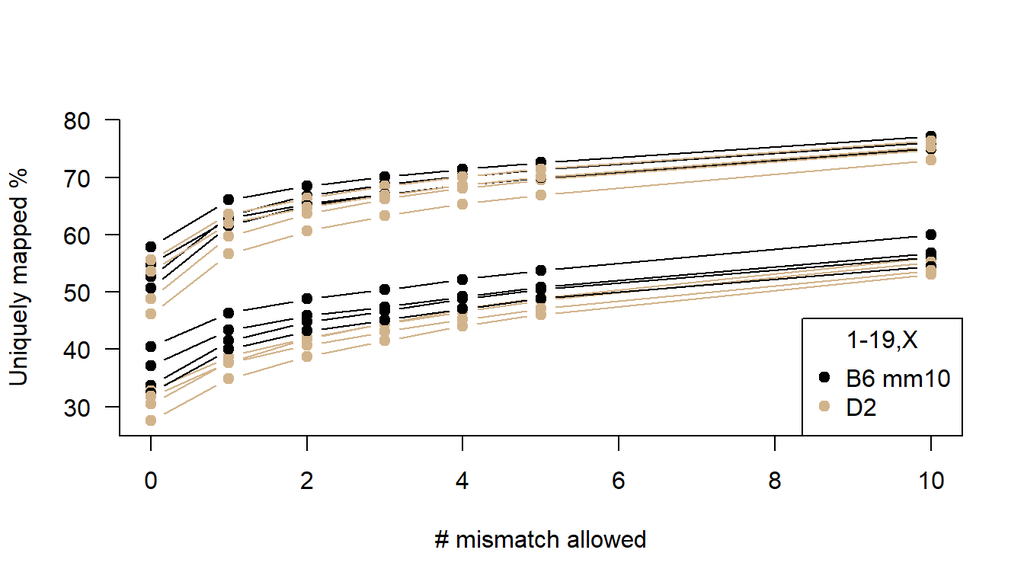

```r
# all samples in 1 graph with segments per sample
par(mfrow=c(1,1))
plot(x="",y="", las=1, bty="l", pch=19, xlim=c(0,10), ylim=c(floor(min(B6mm10majorchromosomes[,c("Uniq0","Uniq1","Uniq2","Uniq3","Uniq4","Uniq5","Uniq10")],D2majorchromosomes[,c("Uniq0","Uniq1","Uniq2","Uniq3","Uniq4","Uniq5","Uniq10")])),ceiling(max(B6mm10majorchromosomes[,c("Uniq0","Uniq1","Uniq2","Uniq3","Uniq4","Uniq5","Uniq10")],D2majorchromosomes[,c("Uniq0","Uniq1","Uniq2","Uniq3","Uniq4","Uniq5","Uniq10")]))), xlab="# mismatch allowed", ylab="Uniquely mapped %")
for(mysample in rownames(B6mm10majorchromosomes)){
  # on B6 mm10 reference
  points(c(0:5,10),B6mm10majorchromosomes[mysample,c("Uniq0","Uniq1","Uniq2","Uniq3","Uniq4","Uniq5","Uniq10")], type="b", pch=19)
  points(c(0:5,10),D2majorchromosomes[mysample,c("Uniq0","Uniq1","Uniq2","Uniq3","Uniq4","Uniq5","Uniq10")], las=1, bty="l", type="b", pch=19, col="tan")
  legend("bottomright", title="1-19,X", legend=c("B6 mm10", "D2"), pch=19, col=c("black", "tan"), cex=1)
}
```

```r
# calculate diff reference-specific

mean(B6mm10majorchromosomes[CB6samples,"Uniq0"]-D2majorchromosomes[CB6samples,"Uniq0"])
```

```
## [1] 8.91
```

```r
mean(B6mm10majorchromosomes[LB6samples,"Uniq0"]-D2majorchromosomes[LB6samples,"Uniq0"])
```

```
## [1] 9.855
```

```r
mean(D2majorchromosomes[CD2samples,"Uniq0"]-B6mm10majorchromosomes[CD2samples,"Uniq0"])
```

```
## [1] 2.92
```

```r
mean(D2majorchromosomes[LD2samples,"Uniq0"]-B6mm10majorchromosomes[LD2samples,"Uniq0"])
```

```
## [1] -0.78
```

## highest mapping rate

Considering only chromosomes 1 to 19 and X for B6 mm10. Considering all features for D2. (what has the highest mapping rate)

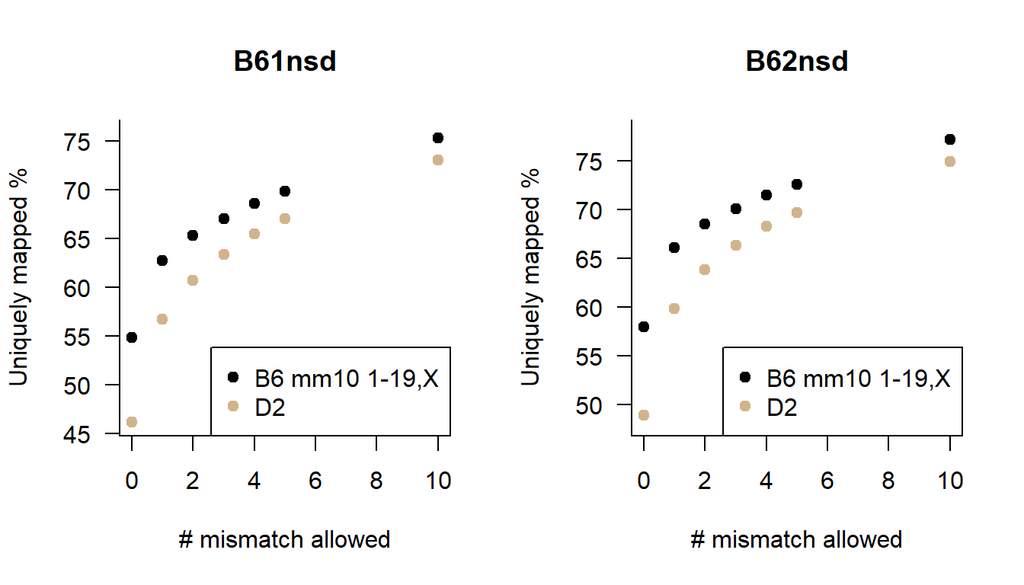

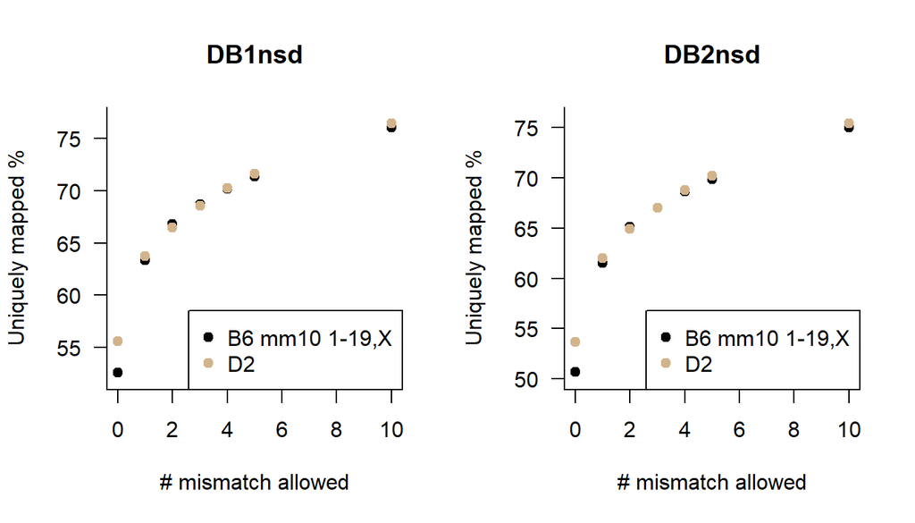

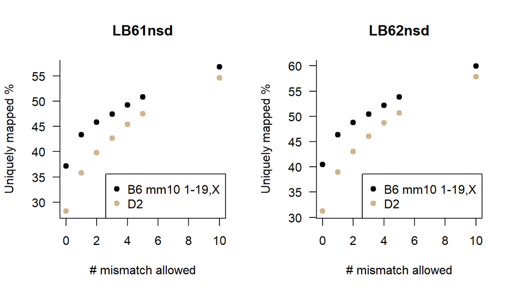

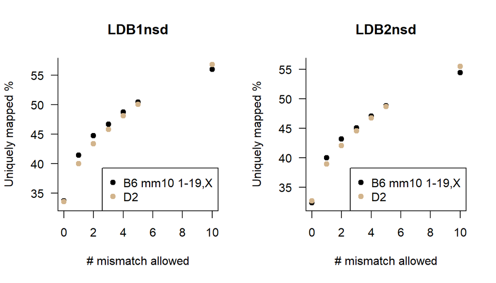

```r
par(mfrow=c(1,2))
for(mysample in rownames(B6mm10majorchromosomes)){
  # on B6 mm10 reference
  plot(c(0:5,10),B6mm10majorchromosomes[mysample,c("Uniq0","Uniq1","Uniq2","Uniq3","Uniq4","Uniq5","Uniq10")], las=1, bty="l", pch=19, ylim=c(floor(min(B6mm10majorchromosomes[mysample,c("Uniq0","Uniq1","Uniq2","Uniq3","Uniq4","Uniq5","Uniq10")],D2[mysample,c("Uniq0","Uniq1","Uniq2","Uniq3","Uniq4","Uniq5","Uniq10")])),ceiling(max(B6mm10majorchromosomes[mysample,c("Uniq0","Uniq1","Uniq2","Uniq3","Uniq4","Uniq5","Uniq10")],D2[mysample,c("Uniq0","Uniq1","Uniq2","Uniq3","Uniq4","Uniq5","Uniq10")]))), xlab="# mismatch allowed", ylab="Uniquely mapped %", main=mysample)
  points(c(0:5,10),D2[mysample,c("Uniq0","Uniq1","Uniq2","Uniq3","Uniq4","Uniq5","Uniq10")], las=1, bty="l", pch=19, col="tan")
  legend("bottomright", legend=c("B6 mm10 1-19,X", "D2"), pch=19, col=c("black", "tan"), cex=1)
}
```